# Supervised Learning : Resampling Procedures for Model Hyperparameter Tuning and Internal Validation

```r
##################################
# Identifying the most predictive variables
##################################
rpartFit.Apparent.CP.001.Pruned.Summary$variable.importance
```

```
##             CheckingAccountStatus.none                               Duration
##                             36.1694738                             25.5883818
##                                 Amount             SavingsAccountBonds.lt.100
##                             23.4460098                             13.9266136
##                                    Age         CheckingAccountStatus.0.to.200
##                             12.1698806                             10.9886136
##                 CreditHistory.Critical            SavingsAccountBonds.Unknown
##                              8.7623987                              6.6785937
##         SavingsAccountBonds.100.to.500                    Property.RealEstate
##                              6.4489710                              6.0175175
##       OtherDebtorsGuarantors.Guarantor              InstallmentRatePercentage
##                              4.9643144                              4.2482033
##                         Purpose.NewCar            OtherDebtorsGuarantors.None
##                              4.1140587                              3.7278926
##              EmploymentDuration.4.to.7                      Property.CarOther
##                              3.6343707                              3.6227029
##                     Property.Insurance             OtherInstallmentPlans.None
##                              3.5239267                              3.4229365
##              EmploymentDuration.1.to.4                        Purpose.UsedCar
##                              3.2604912                              3.2526862
##                       Purpose.Business        SavingsAccountBonds.500.to.1000
##                              2.8973105                              2.7314685
##                EmploymentDuration.gt.7           CheckingAccountStatus.gt.200
##                              2.5011765                              2.4870121
##                  NumberExistingCredits             OtherInstallmentPlans.Bank
##                              2.4018956                              2.3750988
##                 CreditHistory.PaidDuly                    Job.SkilledEmployee
##                              2.1171386                              1.9878199
##            Purpose.Furniture.Equipment               Purpose.Radio.Television
##                              1.6561767                              1.5369792
##                              Telephone                  Job.UnskilledResident
##                              1.4139982                              1.2144198
##                      ResidenceDuration Job.Management.SelfEmp.HighlyQualified
##                              0.8574781                              0.7202881
##                    CreditHistory.Delay              Personal.Female.NotSingle
##                              0.6420244                              0.5866667
##                   Personal.Male.Single       Personal.Male.Divorced.Seperated
##                              0.5866667                              0.3548387
##                           Housing.Rent
##                              0.2993096
```

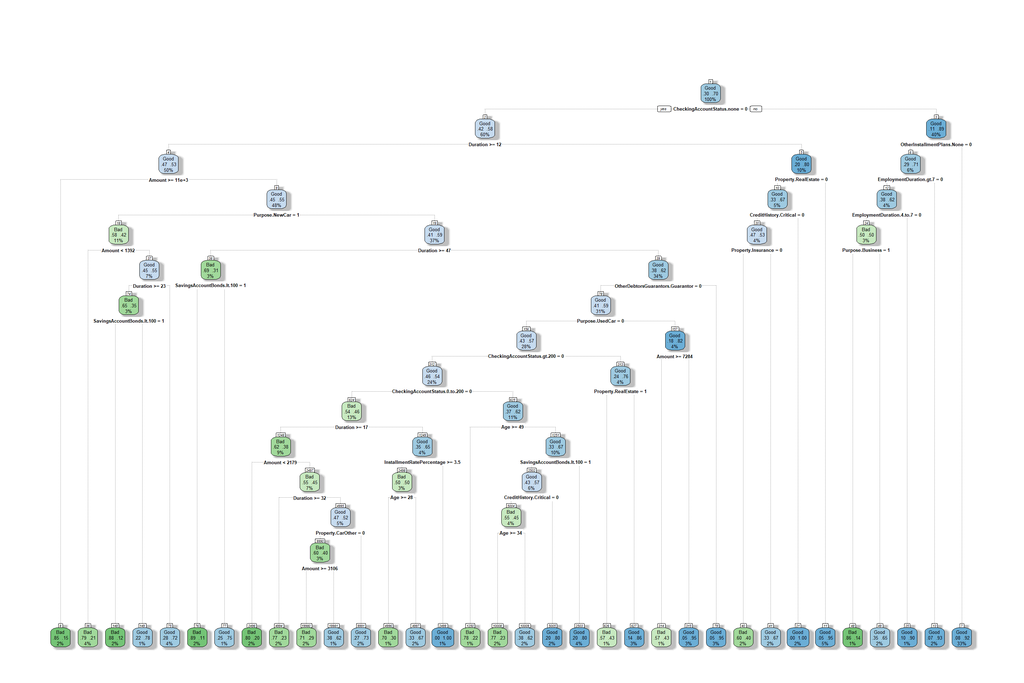

```r
##################################
# Plotting the RPART model structure
##################################
fancyRpartPlot(rpartFit.Apparent.CP.001.Pruned, caption = NULL)
```

```r
##################################
# Evaluating the RPART model
# on the train set
##################################
MA_Train.Evaluated$PredClass.CP.001 <- predict(rpartFit.Apparent.CP.001.Pruned,
                                                 newdata = MA_Train,
                                                 type = "class")
MA_Train.Evaluated$PredCorrect.CP.001 <- ifelse(MA_Train.Evaluated$Class==MA_Train.Evaluated$PredClass.CP.001,1,0)

##################################
# Computing for the
# apparent model performance
##################################
(Train.CP.001 <- mean(MA_Train.Evaluated$PredCorrect.CP.001))
```

```
## [1] 0.84
```

```r
##################################
# Evaluating the RPART model
# on the test set
##################################
MA_Test.Evaluated$PredClass.CP.001 <- predict(rpartFit.Apparent.CP.001.Pruned,
                                                       newdata = MA_Test,
                                                       type = "class")
MA_Test.Evaluated$PredCorrect.CP.001 <- ifelse(MA_Test.Evaluated$Class==MA_Test.Evaluated$PredClass.CP.001,1,0)

##################################
# Computing for the
# external validation model performance
##################################
(Test.CP.001 <- mean(MA_Test.Evaluated$PredCorrect.CP.001))
```

```
## [1] 0.73
```

```r
##################################
# Formulating the RPART model
# using a complexity parameter setting
# equal to 0.005
#################################
rpartFit.Apparent.CP.005 = rpart(Class ~ .,
                                 data = MA_Train,
                                 control = rpart.control(cp = 0.005))

printcp(rpartFit.Apparent.CP.005)
```

```
##
## Classification tree:
## rpart(formula = Class ~ ., data = MA_Train, control = rpart.control(cp = 0.005))
##
## Variables actually used in tree construction:
##  [1] Age                              Amount
##  [3] CheckingAccountStatus.0.to.200   CheckingAccountStatus.gt.200
##  [5] CheckingAccountStatus.none       CreditHistory.Critical
##  [7] Duration                         EmploymentDuration.4.to.7
##  [9] EmploymentDuration.gt.7          InstallmentRatePercentage
## [11] OtherDebtorsGuarantors.Guarantor OtherInstallmentPlans.None
## [13] Property.CarOther                Purpose.Business
## [15] Purpose.NewCar                   Purpose.UsedCar
## [17] SavingsAccountBonds.lt.100
##
## Root node error: 240/800 = 0.3
##
## n= 800
##
##          CP nsplit rel error  xerror     xstd
## 1 0.0291667      0   1.00000 1.00000 0.054006
## 2 0.0270833      5   0.84167 1.05833 0.054860
## 3 0.0208333      7   0.78750 1.04167 0.054625
## 4 0.0166667      8   0.76667 1.00000 0.054006
## 5 0.0141667      9   0.75000 1.02083 0.054322
## 6 0.0097222     15   0.65833 1.03750 0.054566
## 7 0.0083333     21   0.60000 0.98750 0.053811
## 8 0.0052083     24   0.57500 0.99167 0.053877
## 9 0.0050000     28   0.55417 1.00417 0.054070
```

```r
##################################
# Pruning the model
##################################
rpartFit.Apparent.CP.005.Pruned <- prune(rpartFit.Apparent.CP.005, cp = 0.005)

rpartFit.Apparent.CP.005.Pruned.Summary <- summary(rpartFit.Apparent.CP.005.Pruned)
```

```
## Call:
## rpart(formula = Class ~ ., data = MA_Train, control = rpart.control(cp = 0.005))
##   n= 800
##
##            CP nsplit rel error    xerror       xstd
## 1 0.029166667      0 1.0000000 1.0000000 0.05400617
## 2 0.027083333      5 0.8416667 1.0583333 0.05486014
## 3 0.020833333      7 0.7875000 1.0416667 0.05462546
## 4 0.016666667      8 0.7666667 1.0000000 0.05400617
## 5 0.014166667      9 0.7500000 1.0208333 0.05432169
## 6 0.009722222     15 0.6583333 1.0375000 0.05456564
## 7 0.008333333     21 0.6000000 0.9875000 0.05381113
## 8 0.005208333     24 0.5750000 0.9916667 0.05387663
## 9 0.005000000     28 0.5541667 1.0041667 0.05407023
##
## Variable importance
##       CheckingAccountStatus.none                         Duration
##                               19                               13
##                           Amount       SavingsAccountBonds.lt.100
##                               10                                7
##                              Age   CheckingAccountStatus.0.to.200
##                                6                                6
##      SavingsAccountBonds.Unknown   SavingsAccountBonds.100.to.500
##                                3                                3
##           CreditHistory.Critical OtherDebtorsGuarantors.Guarantor
##                                3                                3
##        InstallmentRatePercentage                   Purpose.NewCar
##                                2                                2
##      OtherDebtorsGuarantors.None       OtherInstallmentPlans.None
##                                2                                2
##                  Purpose.UsedCar        EmploymentDuration.4.to.7
##                                2                                2
##                 Purpose.Business  SavingsAccountBonds.500.to.1000
##                                1                                1
##     CheckingAccountStatus.gt.200       OtherInstallmentPlans.Bank
##                                1                                1
##                Property.CarOther          EmploymentDuration.gt.7
##                                1                                1
##              Job.SkilledEmployee        EmploymentDuration.1.to.4
##                                1                                1
```

[output cut: 580 more lines]

```
##
## Node number 10009: 16 observations
##   predicted class=Good  expected loss=0.375  P(node) =0.02
##     class counts:     6    10
##    probabilities: 0.375 0.625
##
## Node number 19980: 17 observations
##   predicted class=Bad   expected loss=0.2941176  P(node) =0.02125
##     class counts:    12     5
##    probabilities: 0.706 0.294
##
## Node number 19981: 8 observations
##   predicted class=Good  expected loss=0.375  P(node) =0.01
##     class counts:     3     5
##    probabilities: 0.375 0.625
```

```r
##################################
# Identifying the most predictive variables
##################################
rpartFit.Apparent.CP.005.Pruned.Summary$variable.importance
```

```
##             CheckingAccountStatus.none                               Duration
##                             36.1694738                             25.2328263
##                                 Amount             SavingsAccountBonds.lt.100
##                             19.8272797                             13.9266136
##                                    Age         CheckingAccountStatus.0.to.200
##                             11.5271393                             10.9886136
##            SavingsAccountBonds.Unknown         SavingsAccountBonds.100.to.500
##                              6.6785937                              6.4489710
##                 CreditHistory.Critical       OtherDebtorsGuarantors.Guarantor
##                              5.0290653                              4.9643144
##              InstallmentRatePercentage                         Purpose.NewCar
##                              4.2482033                              4.1140587
##            OtherDebtorsGuarantors.None             OtherInstallmentPlans.None
##                              3.4407069                              3.4229365
##                        Purpose.UsedCar              EmploymentDuration.4.to.7
##                              3.2526862                              3.0121485
##                       Purpose.Business        SavingsAccountBonds.500.to.1000
##                              2.8973105                              2.7314685
##           CheckingAccountStatus.gt.200             OtherInstallmentPlans.Bank
##                              2.4870121                              2.3750988
##                      Property.CarOther                EmploymentDuration.gt.7
##                              2.3092157                              2.0745098
##                    Job.SkilledEmployee              EmploymentDuration.1.to.4
##                              1.9878199                              1.7911160
##            Purpose.Furniture.Equipment               Purpose.Radio.Television
##                              1.6561767                              1.5369792
##                 CreditHistory.PaidDuly                  NumberExistingCredits
##                              1.4949163                              1.1574512
##                     Property.Insurance                    Property.RealEstate
##                              1.1335296                              0.8633578
##                      ResidenceDuration Job.Management.SelfEmp.HighlyQualified
##                              0.8574781                              0.7202881
##              Personal.Female.NotSingle                   Personal.Male.Single
##                              0.5866667                              0.5866667
##                              Telephone                    CreditHistory.Delay
##                              0.5866667                              0.3548387
##       Personal.Male.Divorced.Seperated                           Housing.Rent
##                              0.3548387                              0.2993096
##                  Job.UnskilledResident
##                              0.1388889
```

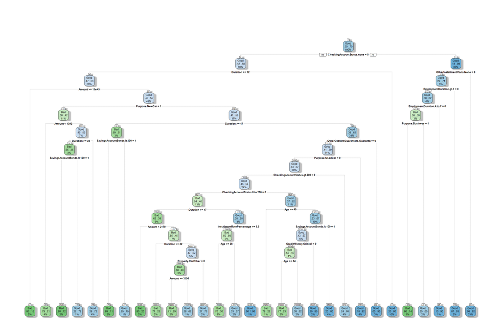

```r
##################################
# Plotting the RPART model structure
##################################
fancyRpartPlot(rpartFit.Apparent.CP.005.Pruned, caption = NULL)
```

```r
##################################
# Evaluating the RPART model
# on the train set
##################################
MA_Train.Evaluated$PredClass.CP.005 <- predict(rpartFit.Apparent.CP.005.Pruned,
                                                        newdata = MA_Train,
                                                        type = "class")
MA_Train.Evaluated$PredCorrect.CP.005 <- ifelse(MA_Train.Evaluated$Class==MA_Train.Evaluated$PredClass.CP.005,1,0)

##################################
# Computing for the
# apparent model performance
##################################
(Train.CP.005 <- mean(MA_Train.Evaluated$PredCorrect.CP.005))
```

```
## [1] 0.83375
```

```r
##################################
# Evaluating the RPART model
# on the test set
##################################
MA_Test.Evaluated$PredClass.CP.005 <- predict(rpartFit.Apparent.CP.005.Pruned,
                                                       newdata = MA_Test,
                                                       type = "class")
MA_Test.Evaluated$PredCorrect.CP.005 <- ifelse(MA_Test.Evaluated$Class==MA_Test.Evaluated$PredClass.CP.005,1,0)

##################################
# Computing for the
# external validation model performance
##################################
(Test.CP.005 <- mean(MA_Test.Evaluated$PredCorrect.CP.005))
```

```
## [1] 0.745
```

```r
##################################
# Formulating the RPART model
# using a complexity parameter setting
# equal to 0.010
#################################
rpartFit.Apparent.CP.010 = rpart(Class ~ .,
                                 data = MA_Train,
                                 control = rpart.control(cp = 0.010))

printcp(rpartFit.Apparent.CP.010)
```

```
##
## Classification tree:
## rpart(formula = Class ~ ., data = MA_Train, control = rpart.control(cp = 0.01))
##
## Variables actually used in tree construction:
##  [1] Age                              Amount
##  [3] CheckingAccountStatus.0.to.200   CheckingAccountStatus.gt.200
##  [5] CheckingAccountStatus.none       Duration
##  [7] OtherDebtorsGuarantors.Guarantor Purpose.NewCar
##  [9] Purpose.UsedCar                  SavingsAccountBonds.lt.100
##
## Root node error: 240/800 = 0.3
##
## n= 800
##
##         CP nsplit rel error  xerror     xstd
## 1 0.029167      0   1.00000 1.00000 0.054006
## 2 0.027083      5   0.84167 0.97917 0.053679
## 3 0.020833      7   0.78750 0.97083 0.053544
## 4 0.016667      8   0.76667 0.92083 0.052696
## 5 0.014167      9   0.75000 0.86250 0.051613
## 6 0.010000     15   0.65833 0.87500 0.051854
```

```r
##################################
# Pruning the model
##################################
rpartFit.Apparent.CP.010.Pruned <- prune(rpartFit.Apparent.CP.010, cp = 0.010)

rpartFit.Apparent.CP.010.Pruned.Summary <- summary(rpartFit.Apparent.CP.010.Pruned)
```

```
## Call:
## rpart(formula = Class ~ ., data = MA_Train, control = rpart.control(cp = 0.01))
##   n= 800
##
##           CP nsplit rel error    xerror       xstd
## 1 0.02916667      0 1.0000000 1.0000000 0.05400617
## 2 0.02708333      5 0.8416667 0.9791667 0.05367869
## 3 0.02083333      7 0.7875000 0.9708333 0.05354430
## 4 0.01666667      8 0.7666667 0.9208333 0.05269619
## 5 0.01416667      9 0.7500000 0.8625000 0.05161266
## 6 0.01000000     15 0.6583333 0.8750000 0.05185366
##
## Variable importance
##       CheckingAccountStatus.none                         Duration
##                               26                               16
##                           Amount       SavingsAccountBonds.lt.100
##                               11                                8
##   CheckingAccountStatus.0.to.200      SavingsAccountBonds.Unknown
##                                8                                4
##   SavingsAccountBonds.100.to.500                              Age
##                                4                                4
## OtherDebtorsGuarantors.Guarantor                   Purpose.NewCar
##                                4                                3
##                  Purpose.UsedCar      OtherDebtorsGuarantors.None
##                                2                                2
##     CheckingAccountStatus.gt.200           CreditHistory.Critical
##                                2                                1
##  SavingsAccountBonds.500.to.1000              Job.SkilledEmployee
##                                1                                1
##        InstallmentRatePercentage        EmploymentDuration.1.to.4
##                                1                                1
##        EmploymentDuration.4.to.7
##                                1
##
## Node number 1: 800 observations,    complexity param=0.02916667
##   predicted class=Good  expected loss=0.3  P(node) =1
##     class counts:   240   560
##    probabilities: 0.300 0.700
##   left son=2 (484 obs) right son=3 (316 obs)
##   Primary splits:
```

[output cut: 282 more lines]

```
##
## Node number 1249: 31 observations
##   predicted class=Good  expected loss=0.3548387  P(node) =0.03875
##     class counts:    11    20
##    probabilities: 0.355 0.645
##
## Node number 1250: 9 observations
##   predicted class=Bad   expected loss=0.2222222  P(node) =0.01125
##     class counts:     7     2
##    probabilities: 0.778 0.222
##
## Node number 1251: 79 observations
##   predicted class=Good  expected loss=0.3291139  P(node) =0.09875
##     class counts:    26    53
##    probabilities: 0.329 0.671
```

```r
##################################
# Identifying the most predictive variables
##################################
rpartFit.Apparent.CP.010.Pruned.Summary$variable.importance
```

```
##       CheckingAccountStatus.none                         Duration
##                       36.1694738                       22.9643483
##                           Amount       SavingsAccountBonds.lt.100
##                       14.7173141                       11.8314467
##   CheckingAccountStatus.0.to.200      SavingsAccountBonds.Unknown
##                       10.9886136                        5.6824730
##   SavingsAccountBonds.100.to.500                              Age
##                        5.4620072                        5.4618791
## OtherDebtorsGuarantors.Guarantor                   Purpose.NewCar
##                        4.9643144                        4.1140587
##                  Purpose.UsedCar      OtherDebtorsGuarantors.None
##                        3.2526862                        2.6003552
##     CheckingAccountStatus.gt.200           CreditHistory.Critical
##                        2.4870121                        2.0602865
##  SavingsAccountBonds.500.to.1000              Job.SkilledEmployee
##                        1.9458261                        1.1303419
##        InstallmentRatePercentage        EmploymentDuration.1.to.4
##                        1.0546549                        0.7533249
##        EmploymentDuration.4.to.7              Property.RealEstate
##                        0.7533249                        0.4166667
##                 Purpose.Business      Purpose.Furniture.Equipment
##                        0.3763021                        0.2605168
##            Job.UnskilledResident
##                        0.1388889
```

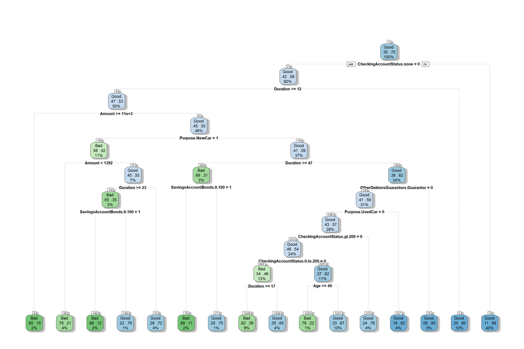

```r
##################################
# Plotting the RPART model structure
##################################
fancyRpartPlot(rpartFit.Apparent.CP.010.Pruned, caption = NULL)
```

```r
##################################
# Evaluating the RPART model
# on the train set
##################################
MA_Train.Evaluated$PredClass.CP.010 <- predict(rpartFit.Apparent.CP.010.Pruned,
                                                        newdata = MA_Train,
                                                        type = "class")
MA_Train.Evaluated$PredCorrect.CP.010 <- ifelse(MA_Train.Evaluated$Class==MA_Train.Evaluated$PredClass.CP.010,1,0)

##################################
# Computing for the
# apparent model performance
##################################
(Train.CP.010 <- mean(MA_Train.Evaluated$PredCorrect.CP.010))
```

```
## [1] 0.8025
```

```r
##################################
# Evaluating the RPART model
# on the test set
##################################
MA_Test.Evaluated$PredClass.CP.010 <- predict(rpartFit.Apparent.CP.010.Pruned,
                                                       newdata = MA_Test,
                                                       type = "class")
MA_Test.Evaluated$PredCorrect.CP.010 <- ifelse(MA_Test.Evaluated$Class==MA_Test.Evaluated$PredClass.CP.010,1,0)

##################################
# Computing for the
# external validation model performance
##################################
(Test.CP.010 <- mean(MA_Test.Evaluated$PredCorrect.CP.010))
```

```
## [1] 0.74
```

```r
##################################
# Formulating the RPART model
# using a complexity parameter setting
# equal to 0.015
#################################
rpartFit.Apparent.CP.015 = rpart(Class ~ .,
                                 data = MA_Train,
                                 control = rpart.control(cp = 0.015))

printcp(rpartFit.Apparent.CP.015)
```

```
##
## Classification tree:
## rpart(formula = Class ~ ., data = MA_Train, control = rpart.control(cp = 0.015))
##
## Variables actually used in tree construction:
## [1] Amount                     CheckingAccountStatus.none
## [3] Duration                   Purpose.NewCar
## [5] SavingsAccountBonds.lt.100
##
## Root node error: 240/800 = 0.3
##
## n= 800
##
##         CP nsplit rel error  xerror     xstd
## 1 0.029167      0   1.00000 1.00000 0.054006
## 2 0.027083      5   0.84167 0.98333 0.053745
## 3 0.020833      7   0.78750 1.00417 0.054070
## 4 0.016667      8   0.76667 0.99583 0.053942
## 5 0.015000      9   0.75000 0.99167 0.053877
```

```r
##################################
# Pruning the model
##################################
rpartFit.Apparent.CP.015.Pruned <- prune(rpartFit.Apparent.CP.015, cp = 0.015)

rpartFit.Apparent.CP.015.Pruned.Summary <- summary(rpartFit.Apparent.CP.015.Pruned)
```

```
## Call:
## rpart(formula = Class ~ ., data = MA_Train, control = rpart.control(cp = 0.015))
##   n= 800
##
##           CP nsplit rel error    xerror       xstd
## 1 0.02916667      0 1.0000000 1.0000000 0.05400617
## 2 0.02708333      5 0.8416667 0.9833333 0.05374515
## 3 0.02083333      7 0.7875000 1.0041667 0.05407023
## 4 0.01666667      8 0.7666667 0.9958333 0.05394164
## 5 0.01500000      9 0.7500000 0.9916667 0.05387663
##
## Variable importance
##      CheckingAccountStatus.none                        Duration
##                              32                              18
##                          Amount      SavingsAccountBonds.lt.100
##                              12                              10
##  CheckingAccountStatus.0.to.200     SavingsAccountBonds.Unknown
##                               7                               5
##  SavingsAccountBonds.100.to.500                  Purpose.NewCar
##                               4                               4
##          CreditHistory.Critical SavingsAccountBonds.500.to.1000
##                               2                               2
##                             Age             Job.SkilledEmployee
##                               2                               1
##       InstallmentRatePercentage       EmploymentDuration.1.to.4
##                               1                               1
##       EmploymentDuration.4.to.7
##                               1
##
## Node number 1: 800 observations,    complexity param=0.02916667
##   predicted class=Good  expected loss=0.3  P(node) =1
##     class counts:   240   560
##    probabilities: 0.300 0.700
##   left son=2 (484 obs) right son=3 (316 obs)
##   Primary splits:
##       CheckingAccountStatus.none splits as  LR,          improve=36.169470, (0 missing)
##       CreditHistory.Critical     splits as  LR,          improve=14.535700, (0 missing)
##       Amount                     < 10918   to the right, improve=13.690600, (0 missing)
##       Duration                   < 26.5    to the right, improve=10.957470, (0 missing)
##       SavingsAccountBonds.lt.100 splits as  RL,          improve= 9.839849, (0 missing)
```

[output cut: 163 more lines]

```
##
## Node number 77: 8 observations
##   predicted class=Good  expected loss=0.25  P(node) =0.01
##     class counts:     2     6
##    probabilities: 0.250 0.750
##
## Node number 148: 17 observations
##   predicted class=Bad   expected loss=0.1176471  P(node) =0.02125
##     class counts:    15     2
##    probabilities: 0.882 0.118
##
## Node number 149: 9 observations
##   predicted class=Good  expected loss=0.2222222  P(node) =0.01125
##     class counts:     2     7
##    probabilities: 0.222 0.778
```

```r
##################################
# Identifying the most predictive variables
##################################
rpartFit.Apparent.CP.015.Pruned.Summary$variable.importance
```

```
##      CheckingAccountStatus.none                        Duration
##                      36.1694738                      19.9861370
##                          Amount      SavingsAccountBonds.lt.100
##                      13.3522194                      11.2525205
##  CheckingAccountStatus.0.to.200     SavingsAccountBonds.Unknown
##                       8.4413380                       5.6824730
##  SavingsAccountBonds.100.to.500                  Purpose.NewCar
##                       5.1146514                       4.1140587
##          CreditHistory.Critical SavingsAccountBonds.500.to.1000
##                       2.0602865                       1.9458261
##                             Age             Job.SkilledEmployee
##                       1.7459252                       1.1303419
##       InstallmentRatePercentage       EmploymentDuration.1.to.4
##                       1.0546549                       0.7533249
##       EmploymentDuration.4.to.7             Property.RealEstate
##                       0.7533249                       0.4166667
##           Job.UnskilledResident
##                       0.1388889
```

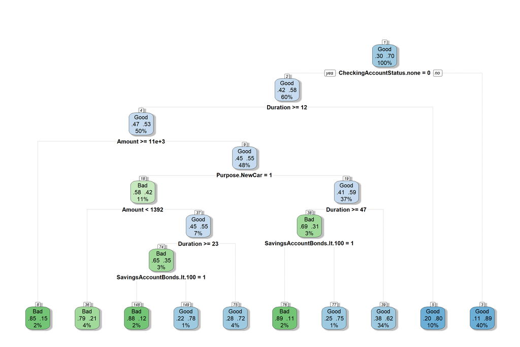

```r
##################################
# Plotting the RPART model structure
##################################
fancyRpartPlot(rpartFit.Apparent.CP.015.Pruned, caption = NULL)
```

```r
##################################
# Evaluating the RPART model
# on the train set
##################################
MA_Train.Evaluated$PredClass.CP.015 <- predict(rpartFit.Apparent.CP.015.Pruned,
                                                        newdata = MA_Train,
                                                        type = "class")
MA_Train.Evaluated$PredCorrect.CP.015 <- ifelse(MA_Train.Evaluated$Class==MA_Train.Evaluated$PredClass.CP.015,1,0)

##################################
# Computing for the
# apparent model performance
##################################
(Train.CP.015 <- mean(MA_Train.Evaluated$PredCorrect.CP.015))
```

```
## [1] 0.775
```

```r
##################################
# Evaluating the RPART model
# on the test set
##################################
MA_Test.Evaluated$PredClass.CP.015 <- predict(rpartFit.Apparent.CP.015.Pruned,
                                                       newdata = MA_Test,
                                                       type = "class")
MA_Test.Evaluated$PredCorrect.CP.015 <- ifelse(MA_Test.Evaluated$Class==MA_Test.Evaluated$PredClass.CP.015,1,0)

##################################
# Computing for the
# external validation model performance
##################################
(Test.CP.015 <- mean(MA_Test.Evaluated$PredCorrect.CP.015))
```

```
## [1] 0.73
```

```r
##################################
# Formulating the RPART model
# using a complexity parameter setting
# equal to 0.020
#################################
rpartFit.Apparent.CP.020 = rpart(Class ~ .,
                                 data = MA_Train,
                                 control = rpart.control(cp = 0.020))

printcp(rpartFit.Apparent.CP.020)
```

```
##
## Classification tree:
## rpart(formula = Class ~ ., data = MA_Train, control = rpart.control(cp = 0.02))
##
## Variables actually used in tree construction:
## [1] Amount                     CheckingAccountStatus.none
## [3] Duration                   Purpose.NewCar
## [5] SavingsAccountBonds.lt.100
##
## Root node error: 240/800 = 0.3
##
## n= 800
##
##         CP nsplit rel error xerror     xstd
## 1 0.029167      0   1.00000 1.0000 0.054006
## 2 0.027083      5   0.84167 1.0208 0.054322
## 3 0.020833      7   0.78750 1.0000 0.054006
## 4 0.020000      8   0.76667 1.0000 0.054006
```

```r
##################################
# Pruning the model
##################################
rpartFit.Apparent.CP.020.Pruned <- prune(rpartFit.Apparent.CP.020, cp = 0.020)

rpartFit.Apparent.CP.020.Pruned.Summary <- summary(rpartFit.Apparent.CP.020.Pruned)
```

```
## Call:
## rpart(formula = Class ~ ., data = MA_Train, control = rpart.control(cp = 0.02))
##   n= 800
##
##           CP nsplit rel error   xerror       xstd
## 1 0.02916667      0 1.0000000 1.000000 0.05400617
## 2 0.02708333      5 0.8416667 1.020833 0.05432169
## 3 0.02083333      7 0.7875000 1.000000 0.05400617
## 4 0.02000000      8 0.7666667 1.000000 0.05400617
##
## Variable importance
##      CheckingAccountStatus.none                        Duration
##                              36                              20
##                          Amount  CheckingAccountStatus.0.to.200
##                              13                               7
##      SavingsAccountBonds.lt.100                  Purpose.NewCar
##                               7                               4
##  SavingsAccountBonds.100.to.500     SavingsAccountBonds.Unknown
##                               3                               3
##          CreditHistory.Critical SavingsAccountBonds.500.to.1000
##                               2                               2
##                             Age       InstallmentRatePercentage
##                               2                               1
##       EmploymentDuration.1.to.4       EmploymentDuration.4.to.7
##                               1                               1
##
## Node number 1: 800 observations,    complexity param=0.02916667
##   predicted class=Good  expected loss=0.3  P(node) =1
##     class counts:   240   560
##    probabilities: 0.300 0.700
##   left son=2 (484 obs) right son=3 (316 obs)
##   Primary splits:
##       CheckingAccountStatus.none splits as  LR,          improve=36.169470, (0 missing)
##       CreditHistory.Critical     splits as  LR,          improve=14.535700, (0 missing)
##       Amount                     < 10918   to the right, improve=13.690600, (0 missing)
##       Duration                   < 26.5    to the right, improve=10.957470, (0 missing)
##       SavingsAccountBonds.lt.100 splits as  RL,          improve= 9.839849, (0 missing)
##   Surrogate splits:
##       CheckingAccountStatus.0.to.200  splits as  RL, agree=0.660, adj=0.139, (0 split)
##       CreditHistory.Critical          splits as  LR, agree=0.627, adj=0.057, (0 split)
```

[output cut: 137 more lines]

```
##
## Node number 75: 29 observations
##   predicted class=Good  expected loss=0.2758621  P(node) =0.03625
##     class counts:     8    21
##    probabilities: 0.276 0.724
##
## Node number 148: 17 observations
##   predicted class=Bad   expected loss=0.1176471  P(node) =0.02125
##     class counts:    15     2
##    probabilities: 0.882 0.118
##
## Node number 149: 9 observations
##   predicted class=Good  expected loss=0.2222222  P(node) =0.01125
##     class counts:     2     7
##    probabilities: 0.222 0.778
```

```r
##################################
# Identifying the most predictive variables
##################################
rpartFit.Apparent.CP.020.Pruned.Summary$variable.importance
```

```
##      CheckingAccountStatus.none                        Duration
##                      36.1694738                      19.9861370
##                          Amount  CheckingAccountStatus.0.to.200
##                      12.7870484                       6.7458251
##      SavingsAccountBonds.lt.100                  Purpose.NewCar
##                       6.7311529                       4.1140587
##  SavingsAccountBonds.100.to.500     SavingsAccountBonds.Unknown
##                       3.4191386                       2.8566183
##          CreditHistory.Critical SavingsAccountBonds.500.to.1000
##                       2.0602865                       1.9458261
##                             Age       InstallmentRatePercentage
##                       1.7459252                       1.0546549
##       EmploymentDuration.1.to.4       EmploymentDuration.4.to.7
##                       0.7533249                       0.7533249
##             Property.RealEstate           Job.UnskilledResident
##                       0.4166667                       0.1388889
```

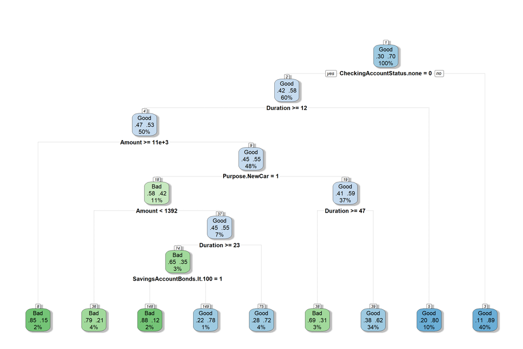

```r
##################################
# Plotting the RPART model structure
##################################
fancyRpartPlot(rpartFit.Apparent.CP.020.Pruned, caption = NULL)
```

```r
##################################
# Evaluating the RPART model
# on the train set
##################################
MA_Train.Evaluated$PredClass.CP.020 <- predict(rpartFit.Apparent.CP.020.Pruned,
                                                        newdata = MA_Train,
                                                        type = "class")
MA_Train.Evaluated$PredCorrect.CP.020 <- ifelse(MA_Train.Evaluated$Class==MA_Train.Evaluated$PredClass.CP.020,1,0)

##################################
# Computing for the
# apparent model performance
##################################
(Train.CP.020 <- mean(MA_Train.Evaluated$PredCorrect.CP.020))
```

```
## [1] 0.77
```

```r
##################################
# Evaluating the RPART model
# on the test set
##################################
MA_Test.Evaluated$PredClass.CP.020 <- predict(rpartFit.Apparent.CP.020.Pruned,
                                                       newdata = MA_Test,
                                                       type = "class")
MA_Test.Evaluated$PredCorrect.CP.020 <- ifelse(MA_Test.Evaluated$Class==MA_Test.Evaluated$PredClass.CP.020,1,0)

##################################
# Computing for the
# external validation model performance
##################################
(Test.CP.020 <- mean(MA_Test.Evaluated$PredCorrect.CP.020))
```

```
## [1] 0.725
```

```r
################################################################################
# Plotting the apparent and external validation model performance
################################################################################
Apparent <- c(Train.CP.001,Train.CP.005,Train.CP.010,Train.CP.015,Train.CP.020)
Test <- c(Test.CP.001,Test.CP.005,Test.CP.010,Test.CP.015,Test.CP.020)
Complexity_Parameter <- c("0.001","0.005","0.010","0.015","0.020")

Performance <- Apparent
Validation <- c(rep("AV: Apparent",5))
ApparentPerformance_Data <- as.data.frame(cbind(Validation,Complexity_Parameter,Performance))
ApparentPerformance_Data$Performance <- as.numeric(as.character(ApparentPerformance_Data$Performance))
ApparentPerformance_Data$Complexity_Parameter <- factor(ApparentPerformance_Data$Complexity_Parameter,
                                                      levels=c("0.001","0.005","0.010","0.015","0.020"))
str(ApparentPerformance_Data)
```

```
## 'data.frame':    5 obs. of  3 variables:
##  $ Validation          : chr  "AV: Apparent" "AV: Apparent" "AV: Apparent" "AV: Apparent" ...
##  $ Complexity_Parameter: Factor w/ 5 levels "0.001","0.005",..: 1 2 3 4 5
##  $ Performance         : num  0.84 0.834 0.802 0.775 0.77
```

```r
ApparentPerformance_Data
```

```
##     Validation Complexity_Parameter Performance
## 1 AV: Apparent                0.001     0.84000
## 2 AV: Apparent                0.005     0.83375
## 3 AV: Apparent                0.010     0.80250
## 4 AV: Apparent                0.015     0.77500
## 5 AV: Apparent                0.020     0.77000
```

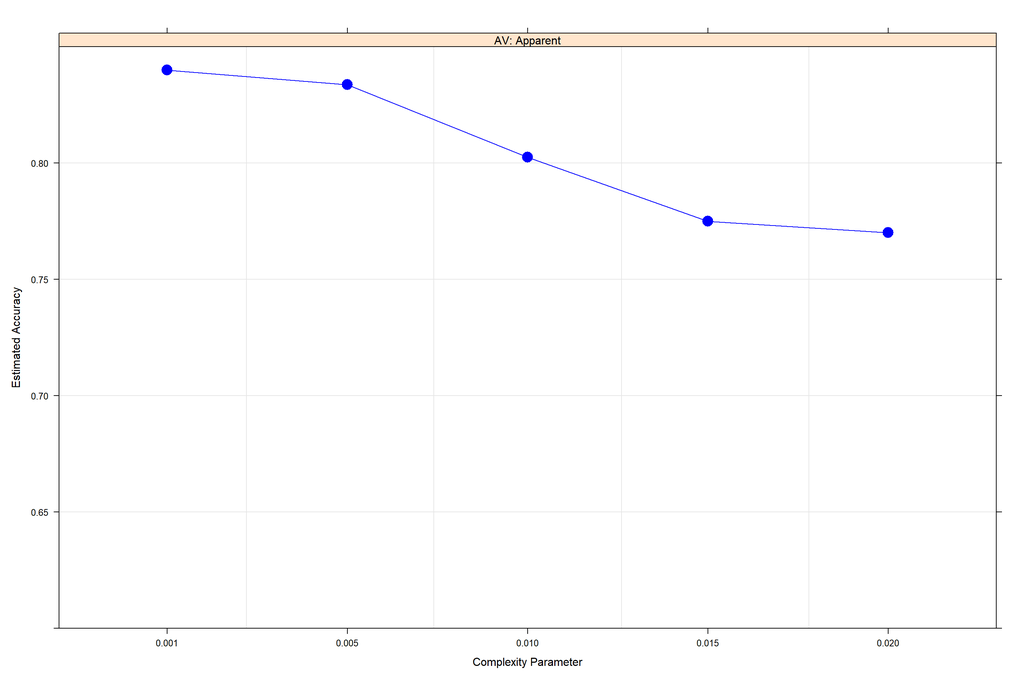

```r
(ApparentPerformance_Plot <- xyplot(Performance ~ Complexity_Parameter | Validation,
                                    data = ApparentPerformance_Data,
                                    ylab = "Estimated Accuracy",
                                    xlab = "Complexity Parameter",
                                    auto.key = list(adj = 1),
                                    ylim = seq(0.60, 0.85, 0.05),
                                    panel = function(x, y) {
                                      panel.grid(h=4, v=4)
                                      panel.xyplot(x,
                                                   y,
                                                   type=c("p","l"),
                                                   pch=16,
                                                   col.symbol="blue",
                                                   col.line="blue",
                                                   cex=2)
                                      }))
```

```r
Performance <- Test
Validation <- c(rep("EV_SSHV: External - Split-Sample",5))
TestPerformance_Data <- as.data.frame(cbind(Validation,Complexity_Parameter,Performance))
TestPerformance_Data$Performance <- as.numeric(as.character(TestPerformance_Data$Performance))
TestPerformance_Data$Complexity_Parameter <- factor(TestPerformance_Data$Complexity_Parameter,
                                                    levels=c("0.001","0.005","0.010","0.015","0.020"))
str(TestPerformance_Data)
```

```
## 'data.frame':    5 obs. of  3 variables:
##  $ Validation          : chr  "EV_SSHV: External - Split-Sample" "EV_SSHV: External - Split-Sample" "EV_SSHV: External - Split-Sample" "EV_SSHV: External - Split-Sample" ...
##  $ Complexity_Parameter: Factor w/ 5 levels "0.001","0.005",..: 1 2 3 4 5
##  $ Performance         : num  0.73 0.745 0.74 0.73 0.725
```

```r
TestPerformance_Data
```

```
##                         Validation Complexity_Parameter Performance
## 1 EV_SSHV: External - Split-Sample                0.001       0.730
## 2 EV_SSHV: External - Split-Sample                0.005       0.745
## 3 EV_SSHV: External - Split-Sample                0.010       0.740
## 4 EV_SSHV: External - Split-Sample                0.015       0.730
## 5 EV_SSHV: External - Split-Sample                0.020       0.725
```

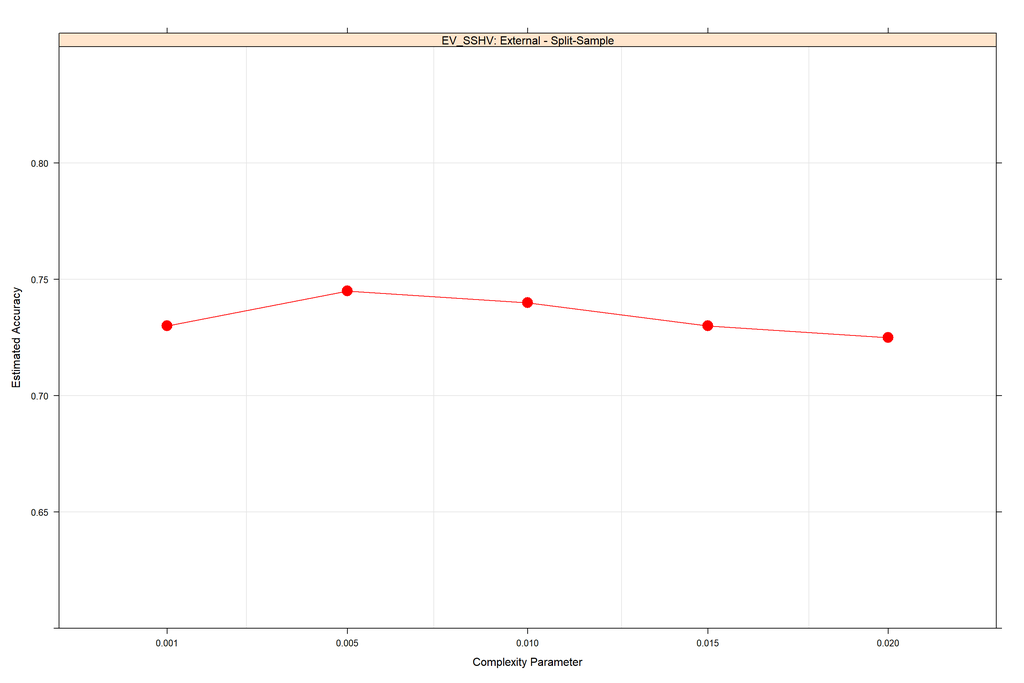

```r
(TestPerformance_Plot <- xyplot(Performance ~ Complexity_Parameter | Validation,
                                    data = TestPerformance_Data,
                                    ylab = "Estimated Accuracy",
                                    xlab = "Complexity Parameter",
                                    auto.key = list(adj = 1),
                                    ylim = seq(0.60, 0.85, 0.05),
                                    panel = function(x, y) {
                                      panel.grid(h=4, v=4)
                                      panel.xyplot(x,
                                                   y,
                                                   type=c("p","l"),
                                                   pch=16,
                                                   col.symbol="red",
                                                   col.line="red",
                                                   cex=2)
                                    }))
```

### 1.5.2 Internal Validation - K-Fold Cross-Validation (IV_KFCV)

[K-Fold Cross-Validation](http://appliedpredictivemodeling.com/) involves dividing the training set after a random shuffle into a user-defined K number of smaller non-overlapping sets called folds. Each unique fold is assigned as the hold-out test data to assess the model trained from the data set collected from all the remaining K-1 folds. The evaluation score is retained but the model is discarded. The process is recursively performed resulting to a total of K fitted models and evaluated on the K hold-out test sets. All K-computed performance measures reported from the process are then averaged to represent the estimated performance of the model. This approach can be computationally expensive and may be highly dependent on how the data was randomly assigned to their respective folds, but does not waste too much data which is a major advantage in problems where the number of samples is very small.  
Model evaluation results:  
**[A]** Internally-validated model performance on train set :  
**[A.1]** Complexity Parameter = 0.001 : 69.38% Accuracy  
**[A.2]** Complexity Parameter = 0.005 : 69.50% Accuracy  
**[A.3]** Complexity Parameter = 0.010 : 70.50% Accuracy (Best)  
**[A.4]** Complexity Parameter = 0.015 : 70.38% Accuracy  
**[A.5]** Complexity Parameter = 0.020 : 69.25% Accuracy

**Code Chunk | Output**

```r
################################################################################
# Applying k-fold cross validation
################################################################################
set.seed(12345678)
grid <- expand.grid(cp=c(0.001,0.005,0.010,0.015,0.020))
rpartFit.CV.5 <- train(Class ~ .,
                         data = MA_Train,
                         method = "rpart",
                         tuneGrid = grid,
                         trControl = trainControl(method = "cv",
                                                  number = 5,
                                                  classProbs = TRUE))

rpartFit.CV.5$results
```

```
##      cp Accuracy     Kappa AccuracySD    KappaSD
## 1 0.001  0.69375 0.2433436 0.02688227 0.05950434
## 2 0.005  0.69500 0.2418830 0.02911454 0.06405609
## 3 0.010  0.70500 0.2308807 0.03168448 0.06750406
## 4 0.015  0.70375 0.2135092 0.02404423 0.05470701
## 5 0.020  0.69250 0.1845879 0.02436699 0.05604208
```

```r
################################################################################
# Plotting the internal model validation performance
# Applying k-fold cross validation
################################################################################
CV.5 <- rpartFit.CV.5$results$Accuracy
CV.5.UCL <- rpartFit.CV.5$results$Accuracy+2*rpartFit.CV.5$results$AccuracySD
CV.5.LCL <- rpartFit.CV.5$results$Accuracy-2*rpartFit.CV.5$results$AccuracySD
Complexity_Parameter <- c("0.001","0.005","0.010","0.015","0.020")

Performance <- CV.5
Validation <- c(rep("IV_KFCV: Internal - K-Fold CV",5))
CV.5Performance_Data <- as.data.frame(cbind(Validation,Complexity_Parameter,Performance,CV.5.UCL,CV.5.LCL))
CV.5Performance_Data$Performance <- as.numeric(as.character(CV.5Performance_Data$Performance))
CV.5Performance_Data$CV.5.UCL <- as.numeric(as.character(CV.5Performance_Data$CV.5.UCL))
CV.5Performance_Data$CV.5.LCL <- as.numeric(as.character(CV.5Performance_Data$CV.5.LCL))
CV.5Performance_Data$Complexity_Parameter <- factor(CV.5Performance_Data$Complexity_Parameter,
                                                    levels=c("0.001","0.005","0.010","0.015","0.020"))
str(CV.5Performance_Data)
```

```
## 'data.frame':    5 obs. of  5 variables:
##  $ Validation          : chr  "IV_KFCV: Internal - K-Fold CV" "IV_KFCV: Internal - K-Fold CV" "IV_KFCV: Internal - K-Fold CV" "IV_KFCV: Internal - K-Fold CV" ...
##  $ Complexity_Parameter: Factor w/ 5 levels "0.001","0.005",..: 1 2 3 4 5
##  $ Performance         : num  0.694 0.695 0.705 0.704 0.692
##  $ CV.5.UCL            : num  0.748 0.753 0.768 0.752 0.741
##  $ CV.5.LCL            : num  0.64 0.637 0.642 0.656 0.644
```

```r
CV.5Performance_Data
```

```
##                      Validation Complexity_Parameter Performance  CV.5.UCL
## 1 IV_KFCV: Internal - K-Fold CV                0.001     0.69375 0.7475145
## 2 IV_KFCV: Internal - K-Fold CV                0.005     0.69500 0.7532291
## 3 IV_KFCV: Internal - K-Fold CV                0.010     0.70500 0.7683690
## 4 IV_KFCV: Internal - K-Fold CV                0.015     0.70375 0.7518385
## 5 IV_KFCV: Internal - K-Fold CV                0.020     0.69250 0.7412340
##    CV.5.LCL
## 1 0.6399855
## 2 0.6367709
## 3 0.6416310
## 4 0.6556615
## 5 0.6437660
```

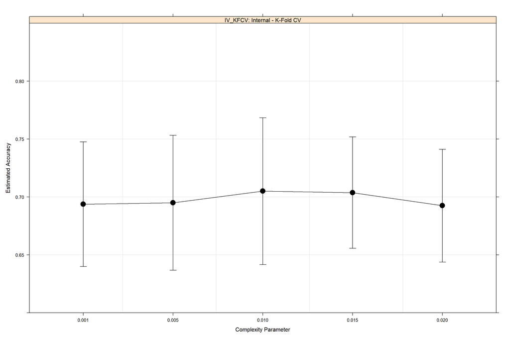

```r
(CV.5Performance_Plot <- xyplot(Performance ~ Complexity_Parameter | Validation,
                                    data = CV.5Performance_Data,
                                    ylab = "Estimated Accuracy",
                                    xlab = "Complexity Parameter",
                                    auto.key = list(adj = 1),
                                    ylim = seq(0.60, 0.85, 0.05),
                                    panel = function(x, y) {
                                      panel.grid(h=4, v=4)
                                      panel.xyplot(x,
                                                   y,
                                                   type=c("p","l"),
                                                   pch=16,
                                                   col.symbol="black",
                                                   col.line="black",
                                                   cex=2)
                                      panel.arrows(x0 = as.numeric(x),
                                                   x1 = as.numeric(x),
                                                   y0 = CV.5Performance_Data$CV.5.LCL,
                                                   y1 = CV.5Performance_Data$CV.5.UCL,
                                                   length = 0.10, angle = 90, code = 3, lend = 2)
                                    }))
```

### 1.5.3 Internal Validation - Repeated K-Fold Cross-Validation (IV_RKFCV)

[Repeated K-Fold Cross-Validation](http://appliedpredictivemodeling.com/) improves on the potentially noisy estimate of model performance via K-Fold cross-validation. Each time the procedure is run, a different split of the dataset into K folds can be implemented, and in turn, the distribution of performance scores can be different, resulting in a different mean estimate of model performance. The amount of difference in the estimated performance from one run of K-Fold cross-validation to another is dependent upon the model that is being used and on the data set itself. One solution to reduce the noise in the estimated model performance is by simply repeating the cross-validation procedure multiple times using different random seeds and reporting the mean result across all folds from all runs. This will reduce the bias in the model’s estimated performance by generating a more accurate estimate of the true unknown underlying mean performance of the model on the data set.  
Model evaluation results:  
**[A]** Internally-validated model performance on train set :  
**[A.1]** Complexity Parameter = 0.001 : 70.66% Accuracy  
**[A.2]** Complexity Parameter = 0.005 : 70.94% Accuracy  
**[A.3]** Complexity Parameter = 0.010 : 72.01% Accuracy (Best)  
**[A.4]** Complexity Parameter = 0.015 : 71.54% Accuracy  
**[A.5]** Complexity Parameter = 0.020 : 71.24% Accuracy

**Code Chunk | Output**

```r
################################################################################
# Applying repeated k-fold cross validation
################################################################################
set.seed(12345678)
grid <- expand.grid(cp=c(0.001,0.005,0.010,0.015,0.020))

rpartFit.RCV.10 <- train(Class ~ .,
                        data = MA_Train,
                        method = "rpart",
                        tuneGrid = grid,
                        trControl = trainControl(method = "repeatedcv",
                                                 repeats = 10,
                                                 number = 5,
                                                 classProbs = TRUE))

rpartFit.RCV.10$results
```

```
##      cp Accuracy     Kappa AccuracySD    KappaSD
## 1 0.001 0.706625 0.2753633 0.03288843 0.07591095
## 2 0.005 0.709375 0.2759455 0.03341362 0.07762500
## 3 0.010 0.720125 0.2801409 0.03106553 0.08147916
## 4 0.015 0.715375 0.2590690 0.03162303 0.08157790
## 5 0.020 0.712375 0.2380722 0.03267150 0.08628021
```

```r
################################################################################
# Plotting the internal model validation performance
# Applying repeated k-fold cross validation
################################################################################
RCV.10 <- rpartFit.RCV.10$results$Accuracy
RCV.10.UCL <- rpartFit.RCV.10$results$Accuracy+2*rpartFit.RCV.10$results$AccuracySD
RCV.10.LCL <- rpartFit.RCV.10$results$Accuracy-2*rpartFit.RCV.10$results$AccuracySD
Complexity_Parameter <- c("0.001","0.005","0.010","0.015","0.020")

Performance <- RCV.10
Validation <- c(rep("IV_RKFCV: Internal - Repeated K-Fold CV",5))
RCV.10Performance_Data <- as.data.frame(cbind(Validation,Complexity_Parameter,Performance,RCV.10.UCL,RCV.10.LCL))
RCV.10Performance_Data$Performance <- as.numeric(as.character(RCV.10Performance_Data$Performance))
RCV.10Performance_Data$RCV.10.UCL <- as.numeric(as.character(RCV.10Performance_Data$RCV.10.UCL))
RCV.10Performance_Data$RCV.10.LCL <- as.numeric(as.character(RCV.10Performance_Data$RCV.10.LCL))
RCV.10Performance_Data$Complexity_Parameter <- factor(RCV.10Performance_Data$Complexity_Parameter,
                                                      levels=c("0.001","0.005","0.010","0.015","0.020"))
str(RCV.10Performance_Data)
```

```
## 'data.frame':    5 obs. of  5 variables:
##  $ Validation          : chr  "IV_RKFCV: Internal - Repeated K-Fold CV" "IV_RKFCV: Internal - Repeated K-Fold CV" "IV_RKFCV: Internal - Repeated K-Fold CV" "IV_RKFCV: Internal - Repeated K-Fold CV" ...
##  $ Complexity_Parameter: Factor w/ 5 levels "0.001","0.005",..: 1 2 3 4 5
##  $ Performance         : num  0.707 0.709 0.72 0.715 0.712
##  $ RCV.10.UCL          : num  0.772 0.776 0.782 0.779 0.778
##  $ RCV.10.LCL          : num  0.641 0.643 0.658 0.652 0.647
```

```r
RCV.10Performance_Data
```

```
##                                Validation Complexity_Parameter Performance
## 1 IV_RKFCV: Internal - Repeated K-Fold CV                0.001    0.706625
## 2 IV_RKFCV: Internal - Repeated K-Fold CV                0.005    0.709375
## 3 IV_RKFCV: Internal - Repeated K-Fold CV                0.010    0.720125
## 4 IV_RKFCV: Internal - Repeated K-Fold CV                0.015    0.715375
## 5 IV_RKFCV: Internal - Repeated K-Fold CV                0.020    0.712375
##   RCV.10.UCL RCV.10.LCL
## 1  0.7724019  0.6408481
## 2  0.7762022  0.6425478
## 3  0.7822561  0.6579939
## 4  0.7786211  0.6521289
## 5  0.7777180  0.6470320
```

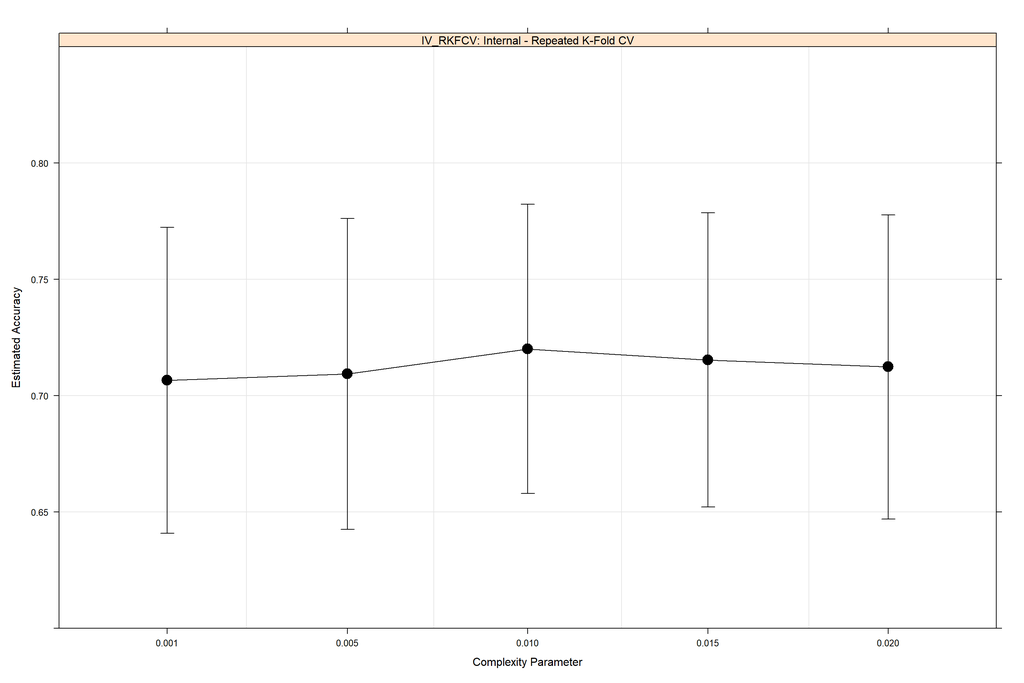

```r
(RCV.10Performance_Plot <- xyplot(Performance ~ Complexity_Parameter | Validation,
                                    data = RCV.10Performance_Data,
                                    ylab = "Estimated Accuracy",
                                    xlab = "Complexity Parameter",
                                    auto.key = list(adj = 1),
                                    ylim = seq(0.60, 0.85, 0.05),
                                    panel = function(x, y) {
                                      panel.grid(h=4, v=4)
                                      panel.xyplot(x,
                                                   y,
                                                   type=c("p","l"),
                                                   pch=16,
                                                   col.symbol="black",
                                                   col.line="black",
                                                   cex=2)
                                      panel.arrows(x0 = as.numeric(x),
                                                   x1 = as.numeric(x),
                                                   y0 = RCV.10Performance_Data$RCV.10.LCL,
                                                   y1 = RCV.10Performance_Data$RCV.10.UCL,
                                                   length = 0.10, angle = 90, code = 3, lend = 2)
                                    }))
```

### 1.5.4 Internal Validation - Leave-One-Out Cross Validation (IV_LOOCV)

[Leave-One-Out Cross Validation](http://appliedpredictivemodeling.com/) is an extreme configuration of the K-Fold cross-validation where K is set to the number of examples in the data set. It requires one model to be created and evaluated for each sample in the training data set resulting to N models, driving a maximum computational cost. Each observation is considered as the validation set and the rest (N-1) observations are considered as the training set. Given the improved estimate of model performance, LOOCV is appropriate when an accurate estimate of model performance is critical. This particularly case when the data set is small which can lead to model over-fitting during training and biased estimates of model performance. Further, given that no sampling of the training data set is used, this estimation procedure is deterministic, unlike train-test splits and other K-Fold cross-validation confirmations that provide a stochastic estimate of model performance.  
Model evaluation results:  
**[A]** Internally-validated model performance on train set :  
**[A.1]** Complexity Parameter = 0.001 : 65.88% Accuracy  
**[A.2]** Complexity Parameter = 0.005 : 67.38% Accuracy (Best)  
**[A.3]** Complexity Parameter = 0.010 : 66.00% Accuracy  
**[A.4]** Complexity Parameter = 0.015 : 61.88% Accuracy  
**[A.5]** Complexity Parameter = 0.020 : 65.75% Accuracy

**Code Chunk | Output**

```r
################################################################################
# Applying leave-one-out cross validation
################################################################################
set.seed(12345678)
grid <- expand.grid(cp=c(0.001,0.005,0.010,0.015,0.020))

rpartFit.LOOCV <- train(Class ~ .,
                   data = MA_Train,
                   method = "rpart",
                   tuneGrid = grid,
                   trControl = trainControl(method = "LOOCV",
                                            classProbs = TRUE))

rpartFit.LOOCV$results
```

```
##      cp Accuracy       Kappa
## 1 0.001  0.65875  0.15217391
## 2 0.005  0.67375  0.16878981
## 3 0.010  0.66000  0.11458333
## 4 0.015  0.61875 -0.04595336
## 5 0.020  0.65750  0.02698864
```

```r
################################################################################
# Plotting the internal model validation performance
# Applying leave-one-out cross validation
################################################################################
LOOCV <- rpartFit.LOOCV$results$Accuracy
Complexity_Parameter <- c("0.001","0.005","0.010","0.015","0.020")

Performance <- LOOCV
Validation <- c(rep("IV_LOOCV: Internal - LOOCV",5))
LOOCVPerformance_Data <- as.data.frame(cbind(Validation,Complexity_Parameter,Performance))
LOOCVPerformance_Data$Performance <- as.numeric(as.character(LOOCVPerformance_Data$Performance))
LOOCVPerformance_Data$Complexity_Parameter <- factor(LOOCVPerformance_Data$Complexity_Parameter,
                                                     levels=c("0.001","0.005","0.010","0.015","0.020"))
str(LOOCVPerformance_Data)
```

```
## 'data.frame':    5 obs. of  3 variables:
##  $ Validation          : chr  "IV_LOOCV: Internal - LOOCV" "IV_LOOCV: Internal - LOOCV" "IV_LOOCV: Internal - LOOCV" "IV_LOOCV: Internal - LOOCV" ...
##  $ Complexity_Parameter: Factor w/ 5 levels "0.001","0.005",..: 1 2 3 4 5
##  $ Performance         : num  0.659 0.674 0.66 0.619 0.657
```

```r
LOOCVPerformance_Data
```

```
##                   Validation Complexity_Parameter Performance
## 1 IV_LOOCV: Internal - LOOCV                0.001     0.65875
## 2 IV_LOOCV: Internal - LOOCV                0.005     0.67375
## 3 IV_LOOCV: Internal - LOOCV                0.010     0.66000
## 4 IV_LOOCV: Internal - LOOCV                0.015     0.61875
## 5 IV_LOOCV: Internal - LOOCV                0.020     0.65750
```

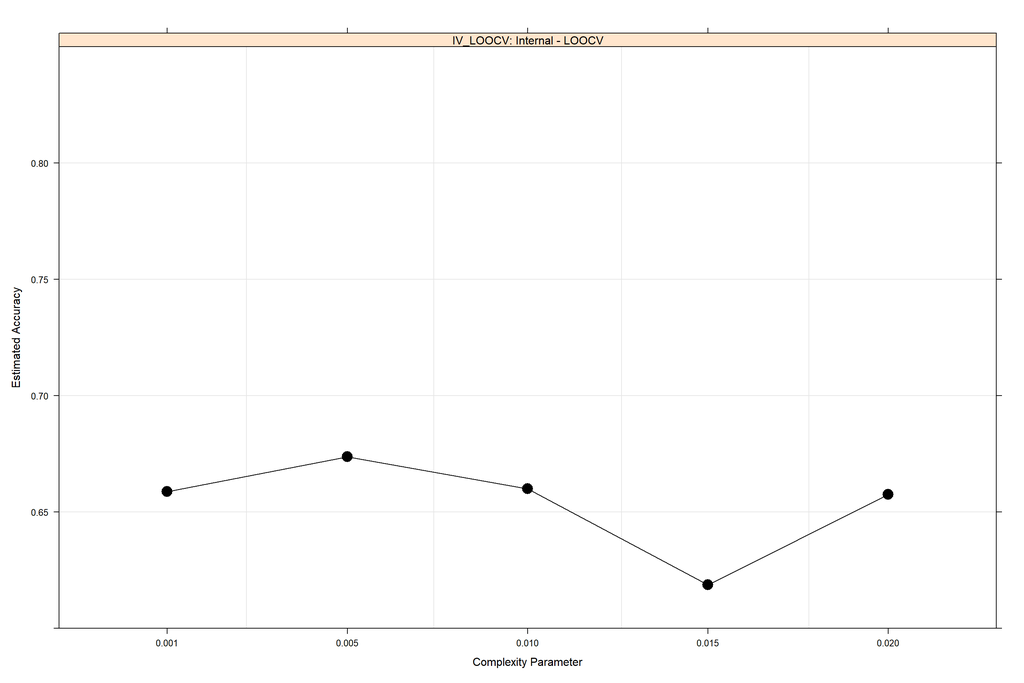

```r
(LOOCVPerformance_Plot <- xyplot(Performance ~ Complexity_Parameter | Validation,
                                    data = LOOCVPerformance_Data,
                                    ylab = "Estimated Accuracy",
                                    xlab = "Complexity Parameter",
                                    auto.key = list(adj = 1),
                                    ylim = seq(0.60, 0.85, 0.05),
                                    panel = function(x, y) {
                                      panel.grid(h=4, v=4)
                                      panel.xyplot(x,
                                                   y,
                                                   type=c("p","l"),
                                                   pch=16,
                                                   col.symbol="black",
                                                   col.line="black",
                                                   cex=2)
                                    }))
```

### 1.5.5 Internal Validation - Leave-Group-Out Cross Validation (IV_LGOCV)

[Leave-Group-Out Cross Validation](http://appliedpredictivemodeling.com/) is also referred to as the Monte Carlo or shuffle-split cross-validation, which repeatedly creates multiple random splits of the data into training and test sets, given a defined train-test proportion and the number of iterations. The process involves fitting the model on the train data set in that iteration and calculating the accuracy of the fitted model on the test data set. Model performance is summarized by taking the average of all the test errors. The bias of the resampling technique decreases as the amount of data in the subset approaches that in the modelling set. While increasing the number of repetitions has the effect of decreasing the uncertainty of the performance estimates.  
Model evaluation results:  
**[A]** Internally-validated model performance on train set :  
**[A.1]** Complexity Parameter = 0.001 : 70.18% Accuracy  
**[A.2]** Complexity Parameter = 0.005 : 70.60% Accuracy  
**[A.3]** Complexity Parameter = 0.010 : 71.21% Accuracy  
**[A.4]** Complexity Parameter = 0.015 : 71.23% Accuracy (Best)  
**[A.5]** Complexity Parameter = 0.020 : 71.11% Accuracy

**Code Chunk | Output**

```r
################################################################################
# Applying leave-group-out cross validation
################################################################################
set.seed(12345678)
grid <- expand.grid(cp=c(0.001,0.005,0.010,0.015,0.020))

rpartFit.LGOCV <- train(Class ~ .,
                        data = MA_Train,
                        method = "rpart",
                        tuneGrid = grid,
                        trControl = trainControl(method = "LGOCV",
                                                 number = 500,
                                                 p = 0.70,
                                                 classProbs = TRUE))

rpartFit.LGOCV$results
```

```
##      cp  Accuracy     Kappa AccuracySD    KappaSD
## 1 0.001 0.7017917 0.2620663 0.02806485 0.06606339
## 2 0.005 0.7060333 0.2648599 0.02773508 0.06752638
## 3 0.010 0.7121250 0.2632998 0.02485831 0.06411238
## 4 0.015 0.7122667 0.2506467 0.02333020 0.06424203
## 5 0.020 0.7110917 0.2344573 0.02336108 0.07288177
```

```r
################################################################################
# Plotting the internal model validation performance
# Applying leave-group-out cross validation
################################################################################
LGOCV <- rpartFit.LGOCV$results$Accuracy
LGOCV.UCL <- rpartFit.LGOCV$results$Accuracy+2*rpartFit.LGOCV$results$AccuracySD
LGOCV.LCL <- rpartFit.LGOCV$results$Accuracy-2*rpartFit.LGOCV$results$AccuracySD
Complexity_Parameter <- c("0.001","0.005","0.010","0.015","0.020")

Performance <- LGOCV
Validation <- c(rep("IV_LGOCV: Internal - LGOCV",5))
LGOCVPerformance_Data <- as.data.frame(cbind(Validation,Complexity_Parameter,Performance,LGOCV.UCL,LGOCV.LCL))
LGOCVPerformance_Data$Performance <- as.numeric(as.character(LGOCVPerformance_Data$Performance))
LGOCVPerformance_Data$LGOCV.UCL <- as.numeric(as.character(LGOCVPerformance_Data$LGOCV.UCL))
LGOCVPerformance_Data$LGOCV.LCL <- as.numeric(as.character(LGOCVPerformance_Data$LGOCV.LCL))
LGOCVPerformance_Data$Complexity_Parameter <- factor(LGOCVPerformance_Data$Complexity_Parameter,
                                                     levels=c("0.001","0.005","0.010","0.015","0.020"))
str(LGOCVPerformance_Data)
```

```
## 'data.frame':    5 obs. of  5 variables:
##  $ Validation          : chr  "IV_LGOCV: Internal - LGOCV" "IV_LGOCV: Internal - LGOCV" "IV_LGOCV: Internal - LGOCV" "IV_LGOCV: Internal - LGOCV" ...
##  $ Complexity_Parameter: Factor w/ 5 levels "0.001","0.005",..: 1 2 3 4 5
##  $ Performance         : num  0.702 0.706 0.712 0.712 0.711
##  $ LGOCV.UCL           : num  0.758 0.762 0.762 0.759 0.758
##  $ LGOCV.LCL           : num  0.646 0.651 0.662 0.666 0.664
```

```r
LGOCVPerformance_Data
```

```
##                   Validation Complexity_Parameter Performance LGOCV.UCL
## 1 IV_LGOCV: Internal - LGOCV                0.001   0.7017917 0.7579214
## 2 IV_LGOCV: Internal - LGOCV                0.005   0.7060333 0.7615035
## 3 IV_LGOCV: Internal - LGOCV                0.010   0.7121250 0.7618416
## 4 IV_LGOCV: Internal - LGOCV                0.015   0.7122667 0.7589271
## 5 IV_LGOCV: Internal - LGOCV                0.020   0.7110917 0.7578138
##   LGOCV.LCL
## 1 0.6456620
## 2 0.6505632
## 3 0.6624084
## 4 0.6656063
## 5 0.6643695
```

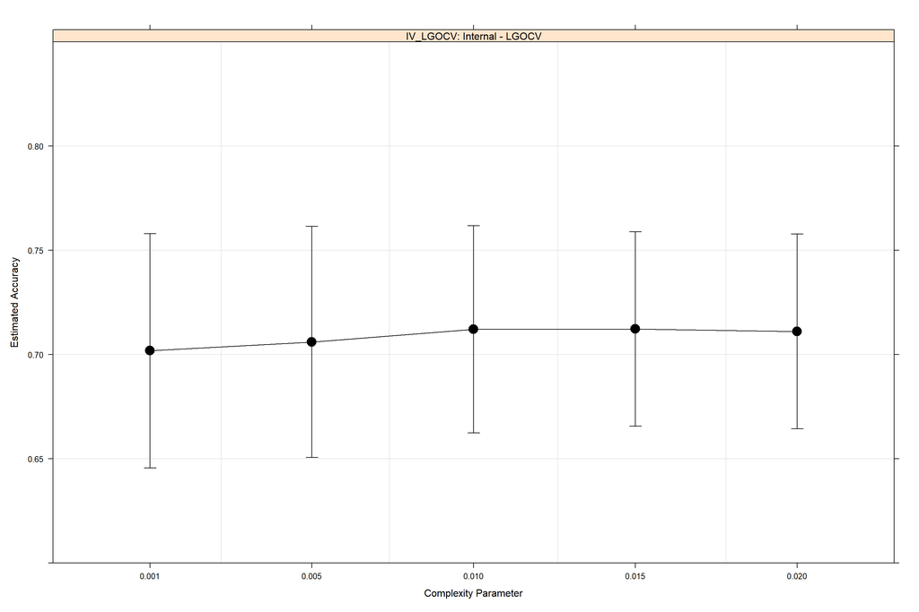

```r
(LGOCVPerformance_Plot <- xyplot(Performance ~ Complexity_Parameter | Validation,
                                    data = LGOCVPerformance_Data,
                                    ylab = "Estimated Accuracy",
                                    xlab = "Complexity Parameter",
                                    auto.key = list(adj = 1),
                                    ylim = seq(0.60, 0.85, 0.05),
                                    panel = function(x, y) {
                                      panel.grid(h=4, v=4)
                                      panel.xyplot(x,
                                                   y,
                                                   type=c("p","l"),
                                                   pch=16,
                                                   col.symbol="black",
                                                   col.line="black",
                                                   cex=2)
                                      panel.arrows(x0 = as.numeric(x),
                                                   x1 = as.numeric(x),
                                                   y0 = LGOCVPerformance_Data$LGOCV.LCL,
                                                   y1 = LGOCVPerformance_Data$LGOCV.UCL,
                                                   length = 0.10, angle = 90, code = 3, lend = 2)
                                    }))
```

### 1.5.6 Internal Validation - Bootstrap Validation (IV_BV)

[Bootstrap Validation](http://appliedpredictivemodeling.com/) takes random samples with replacement from the training set equal to the number of observations in the data set, given a defined number of iterations. Since the sampling is with replacement, there is a very strong likelihood that some training set samples will be represented more than once. As a consequence of this, some training set data points will not be contained in the bootstrap sample. The model is trained on the bootstrap sample and those data points not in that sample, referred to as out-of-bag samples are the unique sets of instances that are not used for model fitting, are predicted as hold-outs. The model performance metric is calculated from each bootstrap sample with all results consolidated and averaged to estimate the overall performance of the model.  
Model evaluation results:  
**[A]** Internally-validated model performance on train set :  
**[A.1]** Complexity Parameter = 0.001 : 69.10% Accuracy  
**[A.2]** Complexity Parameter = 0.005 : 69.75% Accuracy  
**[A.3]** Complexity Parameter = 0.010 : 70.53% Accuracy  
**[A.4]** Complexity Parameter = 0.015 : 71.11% Accuracy  
**[A.5]** Complexity Parameter = 0.020 : 71.24% Accuracy (Best)

**Code Chunk | Output**

```r
################################################################################
# Applying bootstrap validation
################################################################################
set.seed(12345678)
grid <- expand.grid(cp=c(0.001,0.005,0.010,0.015,0.020))

rpartFit.Boot <- train(Class ~ .,
                        data = MA_Train,
                        method = "rpart",
                        tuneGrid = grid,
                        trControl = trainControl(method = "boot",
                                                 number = 500,
                                                 classProbs = TRUE))

rpartFit.Boot$results
```

```
##      cp  Accuracy     Kappa AccuracySD    KappaSD
## 1 0.001 0.6909885 0.2503562 0.02809481 0.06377817
## 2 0.005 0.6974808 0.2571949 0.02781838 0.06370414
## 3 0.010 0.7053319 0.2617308 0.02628519 0.06188814
## 4 0.015 0.7111238 0.2615536 0.02548858 0.06498478
## 5 0.020 0.7123572 0.2546401 0.02533626 0.06716852
```

```r
################################################################################
# Plotting the internal model validation performance
# Applying bootstrap validation
################################################################################
Boot <- rpartFit.Boot$results$Accuracy
Boot.UCL <- rpartFit.Boot$results$Accuracy+2*rpartFit.Boot$results$AccuracySD
Boot.LCL <- rpartFit.Boot$results$Accuracy-2*rpartFit.Boot$results$AccuracySD
Complexity_Parameter <- c("0.001","0.005","0.010","0.015","0.020")

Performance <- Boot
Validation <- c(rep("IV_BV: Internal - Bootstrap",5))
BootPerformance_Data <- as.data.frame(cbind(Validation,Complexity_Parameter,Performance,Boot.UCL,Boot.LCL))
BootPerformance_Data$Performance <- as.numeric(as.character(BootPerformance_Data$Performance))
BootPerformance_Data$Boot.UCL <- as.numeric(as.character(BootPerformance_Data$Boot.UCL))
BootPerformance_Data$Boot.LCL <- as.numeric(as.character(BootPerformance_Data$Boot.LCL))
BootPerformance_Data$Complexity_Parameter <- factor(BootPerformance_Data$Complexity_Parameter,
                                                    levels=c("0.001","0.005","0.010","0.015","0.020"))
str(BootPerformance_Data)
```

```
## 'data.frame':    5 obs. of  5 variables:
##  $ Validation          : chr  "IV_BV: Internal - Bootstrap" "IV_BV: Internal - Bootstrap" "IV_BV: Internal - Bootstrap" "IV_BV: Internal - Bootstrap" ...
##  $ Complexity_Parameter: Factor w/ 5 levels "0.001","0.005",..: 1 2 3 4 5
##  $ Performance         : num  0.691 0.697 0.705 0.711 0.712
##  $ Boot.UCL            : num  0.747 0.753 0.758 0.762 0.763
##  $ Boot.LCL            : num  0.635 0.642 0.653 0.66 0.662
```

```r
BootPerformance_Data
```

```
##                    Validation Complexity_Parameter Performance  Boot.UCL
## 1 IV_BV: Internal - Bootstrap                0.001   0.6909885 0.7471781
## 2 IV_BV: Internal - Bootstrap                0.005   0.6974808 0.7531176
## 3 IV_BV: Internal - Bootstrap                0.010   0.7053319 0.7579023
## 4 IV_BV: Internal - Bootstrap                0.015   0.7111238 0.7621010
## 5 IV_BV: Internal - Bootstrap                0.020   0.7123572 0.7630297
##    Boot.LCL
## 1 0.6347989
## 2 0.6418440
## 3 0.6527615
## 4 0.6601466
## 5 0.6616847
```

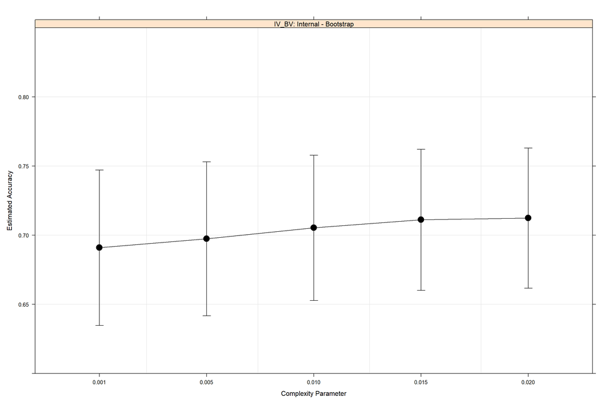

```r
(BootPerformance_Plot <- xyplot(Performance ~ Complexity_Parameter | Validation,
                                    data = BootPerformance_Data,
                                    ylab = "Estimated Accuracy",
                                    xlab = "Complexity Parameter",
                                    auto.key = list(adj = 1),
                                    ylim = seq(0.60, 0.85, 0.05),
                                    panel = function(x, y) {
                                      panel.grid(h=4, v=4)
                                      panel.xyplot(x,
                                                   y,
                                                   type=c("p","l"),
                                                   pch=16,
                                                   col.symbol="black",
                                                   col.line="black",
                                                   cex=2)
                                      panel.arrows(x0 = as.numeric(x),
                                                   x1 = as.numeric(x),
                                                   y0 = BootPerformance_Data$Boot.LCL,
                                                   y1 = BootPerformance_Data$Boot.UCL,
                                                   length = 0.10, angle = 90, code = 3, lend = 2)
                                      }))
```

### 1.5.7 Internal Validation - Bootstrap 0.632 Validation (IV_B632V)

**Code Chunk | Output**

```r
################################################################################
# Applying bootstrap 0.632 validation
################################################################################
set.seed(12345678)
grid <- expand.grid(cp=c(0.001,0.005,0.010,0.015,0.020))

rpartFit.Boot632 <- train(Class ~ .,
                        data = MA_Train,
                        method = "rpart",
                        tuneGrid = grid,
                        trControl = trainControl(method = "boot632",
                                                 number = 500,
                                                 classProbs = TRUE))

rpartFit.Boot632$results
```

```
##      cp  Accuracy     Kappa AccuracySD    KappaSD AccuracyApparent
## 1 0.001 0.7458068 0.3800784 0.02809481 0.06377817          0.84000
## 2 0.005 0.7476114 0.3730317 0.02781838 0.06370414          0.83375
## 3 0.010 0.7410780 0.3446075 0.02628519 0.06188814          0.80250
## 4 0.015 0.7346225 0.2925940 0.02548858 0.06498478          0.77500
## 5 0.020 0.7335628 0.2857039 0.02533626 0.06716852          0.77000
##   KappaApparent
## 1     0.6029777
## 2     0.5720721
## 3     0.4870130
## 4     0.3459302
## 5     0.3390805
```

```r
################################################################################
# Plotting the internal model validation performance
# Applying bootstrap 0.632 validation
################################################################################
Boot632 <- rpartFit.Boot632$results$Accuracy
Boot632.UCL <- rpartFit.Boot632$results$Accuracy+2*rpartFit.Boot632$results$AccuracySD
Boot632.LCL <- rpartFit.Boot632$results$Accuracy-2*rpartFit.Boot632$results$AccuracySD
Complexity_Parameter <- c("0.001","0.005","0.010","0.015","0.020")

Performance <- Boot632
Validation <- c(rep("IV_B632V: Internal - Bootstrap 0.632",5))
Boot632Performance_Data <- as.data.frame(cbind(Validation,Complexity_Parameter,Performance,Boot632.UCL,Boot632.LCL))
Boot632Performance_Data$Performance <- as.numeric(as.character(Boot632Performance_Data$Performance))
Boot632Performance_Data$Boot632.UCL <- as.numeric(as.character(Boot632Performance_Data$Boot632.UCL))
Boot632Performance_Data$Boot632.LCL <- as.numeric(as.character(Boot632Performance_Data$Boot632.LCL))
Boot632Performance_Data$Complexity_Parameter <- factor(Boot632Performance_Data$Complexity_Parameter,
                                                       levels=c("0.001","0.005","0.010","0.015","0.020"))
str(Boot632Performance_Data)
```

```
## 'data.frame':    5 obs. of  5 variables:
##  $ Validation          : chr  "IV_B632V: Internal - Bootstrap 0.632" "IV_B632V: Internal - Bootstrap 0.632" "IV_B632V: Internal - Bootstrap 0.632" "IV_B632V: Internal - Bootstrap 0.632" ...
##  $ Complexity_Parameter: Factor w/ 5 levels "0.001","0.005",..: 1 2 3 4 5
##  $ Performance         : num  0.746 0.748 0.741 0.735 0.734
##  $ Boot632.UCL         : num  0.802 0.803 0.794 0.786 0.784
##  $ Boot632.LCL         : num  0.69 0.692 0.689 0.684 0.683
```

```r
Boot632Performance_Data
```

```
##                             Validation Complexity_Parameter Performance
## 1 IV_B632V: Internal - Bootstrap 0.632                0.001   0.7458068
## 2 IV_B632V: Internal - Bootstrap 0.632                0.005   0.7476114
## 3 IV_B632V: Internal - Bootstrap 0.632                0.010   0.7410780
## 4 IV_B632V: Internal - Bootstrap 0.632                0.015   0.7346225
## 5 IV_B632V: Internal - Bootstrap 0.632                0.020   0.7335628
##   Boot632.UCL Boot632.LCL
## 1   0.8019964   0.6896172
## 2   0.8032482   0.6919747
## 3   0.7936484   0.6885077
## 4   0.7855997   0.6836454
## 5   0.7842353   0.6828903
```

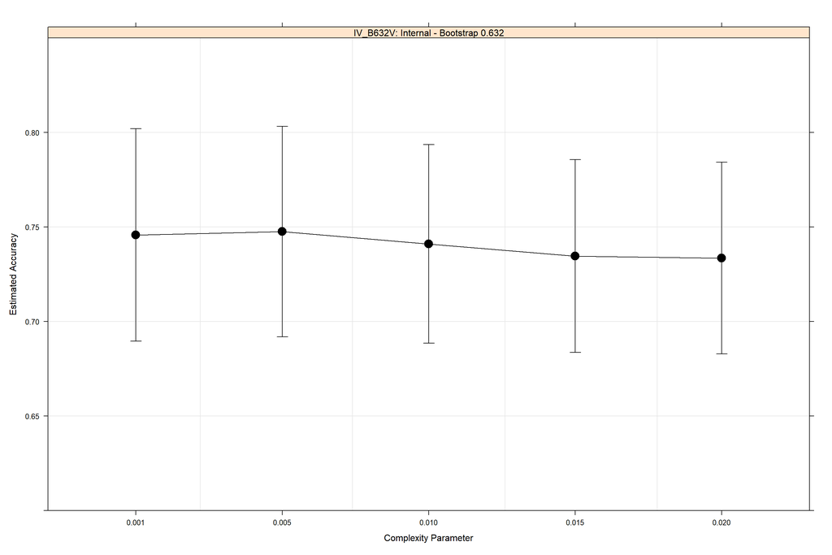

```r
(Boot632Performance_Plot <- xyplot(Performance ~ Complexity_Parameter | Validation,
                                    data = Boot632Performance_Data,
                                    ylab = "Estimated Accuracy",
                                    xlab = "Complexity Parameter",
                                    auto.key = list(adj = 1),
                                    ylim = seq(0.60, 0.85, 0.05),
                                    panel = function(x, y) {
                                      panel.grid(h=4, v=4)
                                      panel.xyplot(x,
                                                   y,
                                                   type=c("p","l"),
                                                   pch=16,
                                                   col.symbol="black",
                                                   col.line="black",
                                                   cex=2)
                                      panel.arrows(x0 = as.numeric(x),
                                                   x1 = as.numeric(x),
                                                   y0 = Boot632Performance_Data$Boot632.LCL,
                                                   y1 = Boot632Performance_Data$Boot632.UCL,
                                                   length = 0.10, angle = 90, code = 3, lend = 2)
                                      }))
```

### 1.5.8 Internal Validation - Bootstrap Validation with Optimism Estimation (IV_BVOE)

[Bootstrap Validation with Optimism Estimation](http://clinicalpredictionmodels.org/) is a further improvement of the original bootstrap process for calculating nearly unbiased and relatively stable estimates of optimism for a specific model performance metric. By subtracting the optimism from the performance metric, a corrected version can be obtained which better accounts for possible overfitting, which has been shown through numerous simulation studies as able to produce much more accurate estimates of true model performance than simply obtaining bootstrap estimates of performance metrics directly. The process involves training a model on a sample dataset, and recording the value of a performance metric of interest. Sufficiently many bootstrap samples are formed by drawing randomly with replacement from the original sample data set. New models are trained on each bootstrap sample, and each corresponding value of the performance metric for each bootstrap-sample-derived model is recorded. Each bootstrap-sample-derived model is applied to the original sample dataset, and the performance metric is measured. Optimism values are estimated by taking the mean of the differences between the the apparent performance of each bootstrap-sample-derived mode and each bootstrap-sample-derived model’s performance when tested on the original sample. Rhe optimism-corrected value of the performance metric is then determined as the difference between the calculated naive values and the estimated optimism.  
Model evaluation results:  
**[A]** Internally-validated model performance on train set :  
**[A.1]** Complexity Parameter = 0.001 : 75.48% Accuracy (Best)  
**[A.2]** Complexity Parameter = 0.005 : 75.28% Accuracy  
**[A.3]** Complexity Parameter = 0.010 : 73.07% Accuracy  
**[A.4]** Complexity Parameter = 0.015 : 71.64% Accuracy  
**[A.5]** Complexity Parameter = 0.020 : 72.14% Accuracy

**Code Chunk | Output**

```r
################################################################################
# Applying bootstrap with optimism estimation validation
################################################################################
set.seed(12345678)
grid <- expand.grid(cp=c(0.001,0.005,0.010,0.015,0.020))

rpartFit.BootOptimism <- train(Class ~ .,
                        data = MA_Train,
                        method = "rpart",
                        tuneGrid = grid,
                        trControl = trainControl(method = "optimism_boot",
                                                 number = 500,
                                                 classProbs = TRUE))

rpartFit.BootOptimism$results
```

```
##      cp  Accuracy     Kappa AccuracySD    KappaSD AccuracyApparent
## 1 0.001 0.7547650 0.3962111 0.02809481 0.06377817          0.84000
## 2 0.005 0.7528225 0.3732562 0.02781838 0.06370414          0.83375
## 3 0.010 0.7306500 0.3068618 0.02628519 0.06188814          0.80250
## 4 0.015 0.7164050 0.1964290 0.02548858 0.06498478          0.77500
## 5 0.020 0.7214225 0.2141386 0.02533626 0.06716852          0.77000
##   KappaApparent AccuracyOptimism KappaOptimism
## 1     0.6029777       -0.0852350    -0.2067665
## 2     0.5720721       -0.0809275    -0.1988158
## 3     0.4870130       -0.0718500    -0.1801512
## 4     0.3459302       -0.0585950    -0.1495012
## 5     0.3390805       -0.0485775    -0.1249418
```

```r
################################################################################
# Plotting the internal model validation performance
# Applying bootstrap with optimism estimation validation
################################################################################
BootOptimism <- rpartFit.BootOptimism$results$Accuracy
BootOptimism.UCL <- rpartFit.BootOptimism$results$Accuracy+2*rpartFit.BootOptimism$results$AccuracySD
BootOptimism.LCL <- rpartFit.BootOptimism$results$Accuracy-2*rpartFit.BootOptimism$results$AccuracySD
Complexity_Parameter <- c("0.001","0.005","0.010","0.015","0.020")

Performance <- BootOptimism
Validation <- c(rep("IV_BVOE: Internal - Bootstrap Optimism",5))
BootOptimismPerformance_Data <- as.data.frame(cbind(Validation,Complexity_Parameter,Performance,BootOptimism.UCL,BootOptimism.LCL))
BootOptimismPerformance_Data$Performance <- as.numeric(as.character(BootOptimismPerformance_Data$Performance))
BootOptimismPerformance_Data$BootOptimism.UCL <- as.numeric(as.character(BootOptimismPerformance_Data$BootOptimism.UCL))
BootOptimismPerformance_Data$BootOptimism.LCL <- as.numeric(as.character(BootOptimismPerformance_Data$BootOptimism.LCL))
BootOptimismPerformance_Data$Complexity_Parameter <- factor(BootOptimismPerformance_Data$Complexity_Parameter,
                                                            levels=c("0.001","0.005","0.010","0.015","0.020"))
str(BootOptimismPerformance_Data)
```

```
## 'data.frame':    5 obs. of  5 variables:
##  $ Validation          : chr  "IV_BVOE: Internal - Bootstrap Optimism" "IV_BVOE: Internal - Bootstrap Optimism" "IV_BVOE: Internal - Bootstrap Optimism" "IV_BVOE: Internal - Bootstrap Optimism" ...
##  $ Complexity_Parameter: Factor w/ 5 levels "0.001","0.005",..: 1 2 3 4 5
##  $ Performance         : num  0.755 0.753 0.731 0.716 0.721
##  $ BootOptimism.UCL    : num  0.811 0.808 0.783 0.767 0.772
##  $ BootOptimism.LCL    : num  0.699 0.697 0.678 0.665 0.671
```

```r
BootOptimismPerformance_Data
```

```
##                               Validation Complexity_Parameter Performance
## 1 IV_BVOE: Internal - Bootstrap Optimism                0.001   0.7547650
## 2 IV_BVOE: Internal - Bootstrap Optimism                0.005   0.7528225
## 3 IV_BVOE: Internal - Bootstrap Optimism                0.010   0.7306500
## 4 IV_BVOE: Internal - Bootstrap Optimism                0.015   0.7164050
## 5 IV_BVOE: Internal - Bootstrap Optimism                0.020   0.7214225
##   BootOptimism.UCL BootOptimism.LCL
## 1        0.8109546        0.6985754
## 2        0.8084593        0.6971857
## 3        0.7832204        0.6780796
## 4        0.7673822        0.6654278
## 5        0.7720950        0.6707500
```

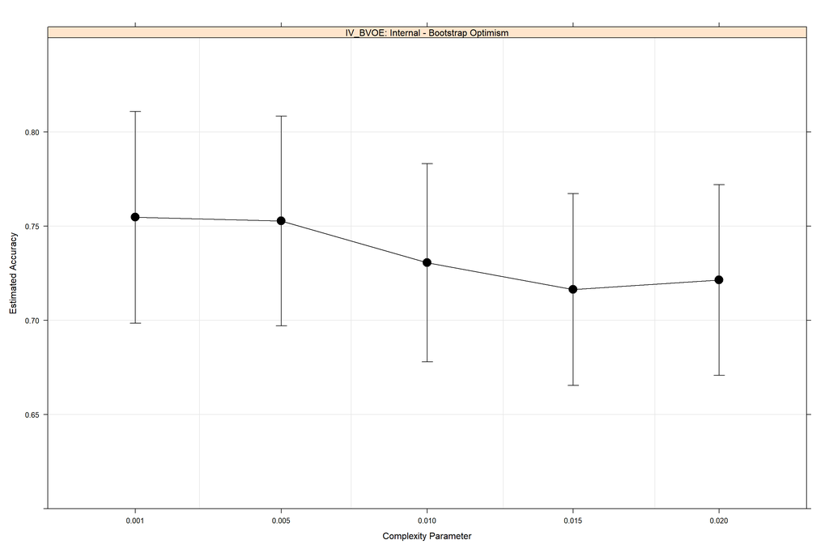

```r
(BootOptimismPerformance_Plot <- xyplot(Performance ~ Complexity_Parameter | Validation,
                                    data = BootOptimismPerformance_Data,
                                    ylab = "Estimated Accuracy",
                                    xlab = "Complexity Parameter",
                                    auto.key = list(adj = 1),
                                    ylim = seq(0.60, 0.85, 0.05),
                                    panel = function(x, y) {
                                      panel.grid(h=4, v=4)
                                      panel.xyplot(x,
                                                   y,
                                                   type=c("p","l"),
                                                   pch=16,
                                                   col.symbol="black",
                                                   col.line="black",
                                                   cex=2)
                                      panel.arrows(x0 = as.numeric(x),
                                                   x1 = as.numeric(x),
                                                   y0 = BootOptimismPerformance_Data$BootOptimism.LCL,
                                                   y1 = BootOptimismPerformance_Data$BootOptimism.UCL,
                                                   length = 0.10, angle = 90, code = 3, lend = 2)
                                      }))
```

## 1.6 Model Evaluation Summary

Model performance comparison:  
**[A]** The best apparent model performance was noted for the most complex model (Complexity Parameter = 0.001). However, this model might have too closely captured patterns of the train set, which may render it unable to generalize well to unseen data. Several internal validation procedures were implemented to estimate model performance on new data.  
**[B]** Various best-performing models were noted for the different internal validation procedures evaluated :  
**[B.1]** **K-Fold Cross Validation** using K=5  
**[B.1.1]** Complexity Parameter = 0.010 : 70.50% Accuracy (Best)  
**[B.1.2]** Complexity Parameter = 0.015 : 70.38% Accuracy (Alternate)  
**[B.2]** **Repeated K-Fold Cross Validation** using K=5, Repeats=10  
**[B.2.1]** Complexity Parameter = 0.010 : 72.01% Accuracy (Best)  
**[B.2.2]** Complexity Parameter = 0.015 : 71.54% Accuracy (Alternate)  
**[B.3]** **Leave-One-Out Cross Validation** using N=800  
**[B.3.1]** Complexity Parameter = 0.005 : 67.38% Accuracy (Best)  
**[B.3.2]** Complexity Parameter = 0.010 : 66.00% Accuracy (Alternate)  
**[B.4]** **Leave-Group-Out Cross Validation** using Iterations=500  
**[B.4.1]** Complexity Parameter = 0.010 : 71.21% Accuracy (Alternate)  
**[B.4.2]** Complexity Parameter = 0.015 : 71.23% Accuracy (Best)  
**[B.5]** **Bootstrap Validation** using Iterations=500  
**[B.5.1]** Complexity Parameter = 0.015 : 71.11% Accuracy (Alternate)  
**[B.5.2]** Complexity Parameter = 0.020 : 71.24% Accuracy (Best)  
**[B.6]** **Bootstrap 0.632 Validation** using Iterations=500  
**[B.6.1]** Complexity Parameter = 0.001 : 74.58% Accuracy (Alternate)  
**[B.6.2]** Complexity Parameter = 0.005 : 74.76% Accuracy (Best)  
**[B.7]** **Bootstrap with Optimism-Estimation Validation** using Iterations=500  
**[B.7.1]** Complexity Parameter = 0.001 : 75.48% Accuracy (Best)  
**[B.7.2]** Complexity Parameter = 0.005 : 75.28% Accuracy (Alternate)  
**[C]** Taken together, the model with Complexity Parameter = 0.010 was chosen as the final model. The best predictors identified from the model ranked based on variable importance are as follows :  
**[C.1]** CheckingAccountStatus.none variable (factor)  
**[C.2]** Duration variable (numeric)  
**[C.3]** Amount variable (numeric)  
**[C.4]** SavingsAccountsBonds.lt.100 variable (factor)  
**[C.5]** CheckingAccountStatus.0.to.200 variable (factor)  
**[C.6]** SavingsAccountBonds.Unknown variable (factor)  
**[C.7]** SavingsAccountBonds.100.to.500 variable (factor)  
**[C.8]** Age variable (numeric)  
**[C.9]** OtherDebtorsGuarantors.Guarantor variable (factor)  
**[C.10]** Purpose.NewCar variable (factor)  
**[C.11]** Purpose.UsedCar variable (factor)  
**[C.12]** OtherDebtorsGuarantors.None variable (factor)  
**[C.13]** CheckingAccountStatus.gt.200 variable (factor)  
**[C.14]** CreditHistory.Critical variable (factor)  
**[C.15]** SavingsAccountBonds.500.to.1000 variable (factor)  
**[C.16]** Job.SkilledEmployee variable (factor)  
**[C.17]** InstallmentRatePercentage variable (numeric)  
**[C.18]** EmploymentDuration.1.to.4 variable (factor)  
**[C.19]** EmploymentDuration.4.to.7 variable (factor)  
**[C.20]** Property.RealEstate variable (factor)  
**[C.21]** Purpose.Business variable (factor)  
**[C.22]** Purpose.Furniture.Equipment variable (factor)  
**[C.23]** Job.UnskilledResident variable (factor)  
**[D]** External validation of the final model (Complexity Parameter = 0.010) on the test data resulted to a 74.00% accuracy. The difference between the apparent and test accuracies for the final model is 6.25% indicating a slight model overfit. It is not, however, the most optimal model, as the candidate model with Complexity Parameter = 0.005 showed a higher externally-validated accuracy at 74.50%. This might indicate the slight difference in characteristics between the train and test sets.  
**[D.1]** Complexity Parameter = 0.010 : 74.00% Accuracy (Final)  
**[D.2]** Complexity Parameter = 0.005 : 74.50% Accuracy (Optimal)

**Code Chunk | Output**

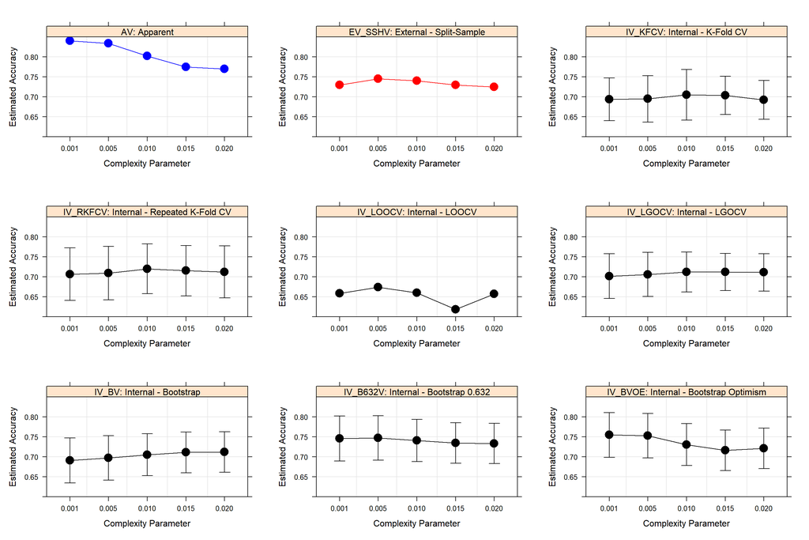

```r
################################################################################
# Consolidating all model performance results
################################################################################
grid.arrange(ApparentPerformance_Plot,
             TestPerformance_Plot,
             CV.5Performance_Plot,
             RCV.10Performance_Plot,
             LOOCVPerformance_Plot,
             LGOCVPerformance_Plot,
             BootPerformance_Plot,
             Boot632Performance_Plot,
             BootOptimismPerformance_Plot,
             ncol = 3)
```

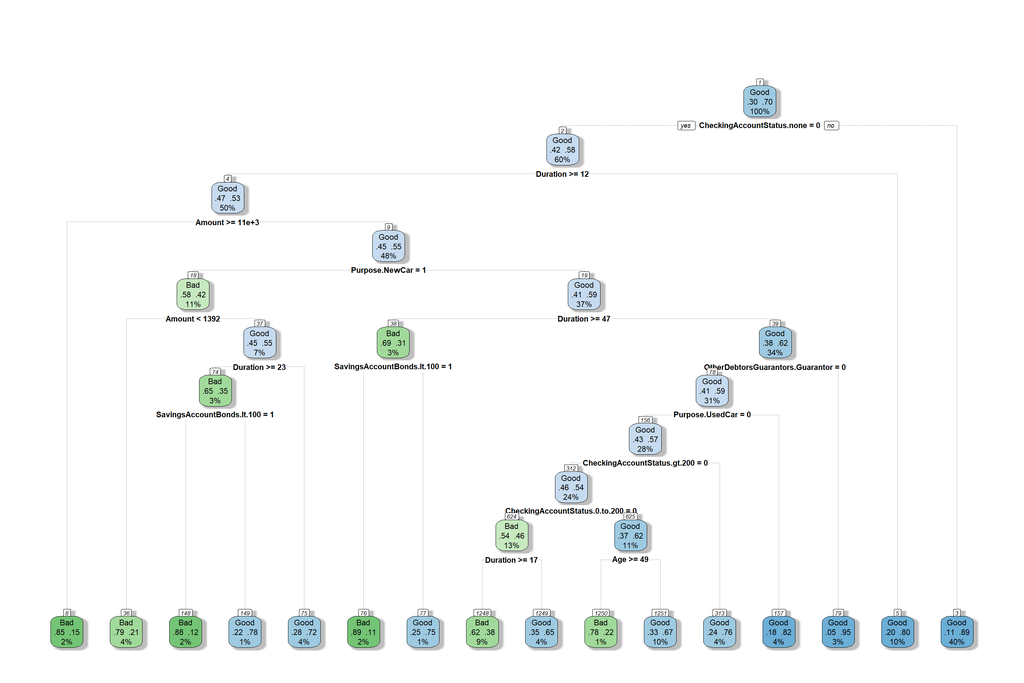

```r
##################################
# Plotting the final RPART model
##################################
fancyRpartPlot(rpartFit.Apparent.CP.010.Pruned, caption = NULL)
```

```r
##################################
# Identifying the most predictive variables
# for the final RPART model
##################################
rpartFit.Apparent.CP.010.Pruned.Summary$variable.importance
```

```
##       CheckingAccountStatus.none                         Duration
##                       36.1694738                       22.9643483
##                           Amount       SavingsAccountBonds.lt.100
##                       14.7173141                       11.8314467
##   CheckingAccountStatus.0.to.200      SavingsAccountBonds.Unknown
##                       10.9886136                        5.6824730
##   SavingsAccountBonds.100.to.500                              Age
##                        5.4620072                        5.4618791
## OtherDebtorsGuarantors.Guarantor                   Purpose.NewCar
##                        4.9643144                        4.1140587
##                  Purpose.UsedCar      OtherDebtorsGuarantors.None
##                        3.2526862                        2.6003552
##     CheckingAccountStatus.gt.200           CreditHistory.Critical
##                        2.4870121                        2.0602865
##  SavingsAccountBonds.500.to.1000              Job.SkilledEmployee
##                        1.9458261                        1.1303419
##        InstallmentRatePercentage        EmploymentDuration.1.to.4
##                        1.0546549                        0.7533249
##        EmploymentDuration.4.to.7              Property.RealEstate
##                        0.7533249                        0.4166667
##                 Purpose.Business      Purpose.Furniture.Equipment
##                        0.3763021                        0.2605168
##            Job.UnskilledResident
##                        0.1388889
```

# **2. References**

**[Book]** [Applied Predictive Modeling](http://appliedpredictivemodeling.com/) by Max Kuhn and Kjell Johnson  
**[Book]** [An Introduction to Statistical Learning](https://www.statlearning.com/) by Gareth James, Daniela Witten, Trevor Hastie and Rob Tibshirani  
**[Book]** [Classification and Regression Trees](https://www.taylorfrancis.com/books/mono/10.1201/9781315139470/classification-regression-trees-leo-breiman) by Leo Breiman  
**[Book]** [Data Modeling Methods](https://bookdown.org/larget_jacob/data-modeling-methods/) by Jacob Larget  
**[Book]** [Clinical Prediction Models](http://clinicalpredictionmodels.org/) by Ewout Steyerberg  
**[R Package]** [caret](https://topepo.github.io/caret/index.html) by Max Kuhn  
**[R Package]** [rpart](https://mran.microsoft.com/web/packages/rpart/rpart.pdf) by Terry Therneau and Beth Atkinson  
**[R Package]** [lattice](https://cran.r-project.org/web/packages/lattice/lattice.pdf) by Deepayan Sarkar  
**[R Package]** [dplyr](https://cran.r-project.org/web/packages/dplyr/index.html/) by Hadley Wickham  
**[R Package]** [moments](https://cran.r-project.org/web/packages/moments/index.html) by Lukasz Komsta and Frederick  
**[R Package]** [skimr](https://cran.r-project.org/web/packages/skimr/skimr.pdf) by Elin Waring  
**[R Package]** [RANN](https://cran.r-project.org/web/packages/RANN/RANN.pdf) by Sunil Arya, David Mount, Samuel Kemp and Gregory Jefferis  
**[R Package]** [corrplot](https://cran.r-project.org/web/packages/corrplot/corrplot.pdf) by Taiyun Wei  
**[R Package]** [tidyverse](https://cran.r-project.org/web/packages/tidyverse/tidyverse.pdf) by Hadley Wickham  
**[R Package]** [lares](https://cran.rstudio.com/web/packages/lares/lares.pdf) by Bernardo Lares  
**[R Package]** [DMwR](https://mran.microsoft.com/snapshot/2016-05-02/web/packages/DMwR/DMwR.pdf) by Luis Torgo  
**[R Package]** [gridExtra](https://cran.r-project.org/web/packages/gridExtra/gridExtra.pdf) by Baptiste Auguie and Anton Antonov  
**[R Package]** [rattle](https://cran.r-project.org/web/packages/rattle/rattle.pdf) by Graham Williams  
**[R Package]** [rpart.plot](https://cran.r-project.org/web/packages/rpart.plot/rpart.plot.pdf) by Stephen Milborrow  
**[R Package]** [RColorBrewer](https://cran.r-project.org/web//packages/RColorBrewer/RColorBrewer.pdf) by Erich Neuwirth  
**[Article]** [Seven Types of Cross-validation](https://www.analyticssteps.com/blogs/7-types-cross-validation) by Soumyaa Rawat  
**[Article]** [What Is Cross-Validation? Comparing Machine Learning Models](https://learn.g2.com/cross-validation) by Amal Joby  
**[Article]** [Different Types of Cross-Validations in Machine Learning and Their Explanations](https://www.turing.com/kb/different-types-of-cross-validations-in-machine-learning-and-their-explanations) by Turing Team  
**[Article]** [Cross-Validation: Evaluating Estimator Performance](https://scikit-learn.org/stable/modules/cross_validation.html) by Sci-Kit Learn Team  
**[Article]** [A Gentle Introduction to K-Fold Cross-Validation](https://machinelearningmastery.com/k-fold-cross-validation/) by Jason Brownlee  
**[Article]** [Repeated k-Fold Cross-Validation for Model Evaluation in Python](https://machinelearningmastery.com/repeated-k-fold-cross-validation-with-python/) by Jason Brownlee  
**[Article]** [LOOCV for Evaluating Machine Learning Algorithms](https://machinelearningmastery.com/loocv-for-evaluating-machine-learning-algorithms/) by Jason Brownlee  
**[Article]** [A Gentle Introduction to the Bootstrap Method](https://machinelearningmastery.com/a-gentle-introduction-to-the-bootstrap-method/) by Jason Brownlee  
**[Article]** [LOOCV (Leave One Out Cross-Validation) in R Programming](https://www.geeksforgeeks.org/loocvleave-one-out-cross-validation-in-r-programming/) by Geeks for Geeks Team  
**[Article]** [Simple and Efficient Bootstrap Validation of Predictive Models Using SAS/STAT® Software](https://www.sas.com/content/dam/SAS/support/en/sas-global-forum-proceedings/2020/4647-2020.pdf) by Isaiah Lankham and Matthew Slaughter  
**[Article]** [Adjusting For Optimism/Overfitting in Measures of Predictive Ability Using Bootstrapping](https://thestatsgeek.com/2014/10/04/adjusting-for-optimismoverfitting-in-measures-of-predictive-ability-using-bootstrapping/) by Jonathan Bartlett  
**[Article]** [Bootstrap_point632_score: The .632 and .632+ Boostrap for Classifier Evaluation](http://rasbt.github.io/mlxtend/user_guide/evaluate/bootstrap_point632_score/) by Sebastian Raschka  
**[Article]** [Bootstrap and Cross-Validation for Evaluating Modelling Strategies](https://www.r-bloggers.com/2016/06/bootstrap-and-cross-validation-for-evaluating-modelling-strategies/) by Peter’s Stats Stuff - R  
**[Article]** [Comparison of Strategies for Validating Binary Logistic Regression Models](http://hbiostat.org/doc/simval.html) by Frank Harrel  
**[Article]** [The caret Package](https://topepo.github.io/caret/index.html) by Max Kuhn  
**[Article]** [A Short Introduction to the caret Package](https://cran.r-project.org/web/packages/caret/vignettes/caret.html) by Max Kuhn  
**[Article]** Caret Package – A Practical Guide to Machine Learning in R by Selva Prabhakaran  
**[Article]** [Tuning Machine Learning Models Using the Caret R Package](https://machinelearningmastery.com/tuning-machine-learning-models-using-the-caret-r-package/) by Jason Brownlee  
**[Article]** [An Introduction to Recursive Partitioning Using the RPART Routines](https://cran.r-project.org/web/packages/rpart/vignettes/longintro.pdf) by Terry Therneau and Elizabeth Atkinson  
**[Article]** [RPART Decision Trees in R](https://www.learnbymarketing.com/tutorials/rpart-decision-trees-in-r/) by Learn By Marketing Team  
**[Article]** [Dot Plots with Lattice](https://www.uni-bamberg.de/fileadmin/uni/fakultaeten/split_lehrstuehle/englische_sprachwissenschaft/MaLT_appendix__Lukas_Soenning_/Dot_plots_with_lattice.html) by Lukas Soenning  
**[Article]** [Lattice Graphs](http://www.sthda.com/english/wiki/lattice-graphs) by STHDA Team  
**[Article]** [ID3, C4.5, CART and Pruning](https://bitmask93.github.io/ml-blog/ID3-C4-5-CART-and-Pruning/) by Jithin J  
**[Article]** [Decision Tree Algorithm Examples In Data Mining](https://www.softwaretestinghelp.com/decision-tree-algorithm-examples-data-mining/) by Software Testing Help Team  
**[Article]** [Decision Tree Algorithm Explained with Examples](https://www.mygreatlearning.com/blog/decision-tree-algorithm/) by Great Learning Team  
**[Article]** [An Overview of Decision Tree Algorithm in Machine Learning](https://mldoodles.com/decision-tree-algorithm/) by ML Doodles Team  
**[Article]** [Decision Tree Classification Algorithm](https://www.javatpoint.com/machine-learning-decision-tree-classification-algorithm) by JavaTPoint Team  
**[Article]** [The Ultimate Guide to Decision Trees for Machine Learning](https://www.keboola.com/blog/decision-trees-machine-learning) by Keboola Team  
**[Article]** [Hyperparameter Tuning for Machine Learning Explained](https://www.mygreatlearning.com/blog/hyperparameter-tuning-explained/) by Great Learning Team  
**[Article]** [Hyperparameter Tuning](https://www.geeksforgeeks.org/hyperparameter-tuning/) by Tarandeep Singh  
**[Article]** [Hyperparameter Optimization Techniques to Improve Your Machine Learning Model’s Performance](https://www.freecodecamp.org/news/hyperparameter-optimization-techniques-machine-learning/) by Davis David  
**[Article]** [What Is Hyperparameter Tuning?](https://aws.amazon.com/what-is/hyperparameter-tuning/) by AWS Team  
**[Article]** Hyperparameter Tuning in Python: a Complete Guide by Shahul ES and Aayush Bajaj  
**[Publication]** [The Little Bootstrap and other Methods for Dimensionality Selection in Regression: X-Fixed Prediction Error](https://www.tandfonline.com/doi/abs/10.1080/01621459.1992.10475276) by Leo Breiman (Journal of the American Statistical Association )  
**[Publication]** [A Leisurely Look at the Bootstrap, the Jackknife, and Cross-Validation](https://www.jstor.org/stable/2685844?origin=crossref) by Bradley Efron and Gail Gong (The American Statistician)  
**[Publication]** [Bootstrap Methods for Standard Errors, Confidence Intervals, and Other Measures of Statistical Accuracy](https://projecteuclid.org/journals/statistical-science/volume-1/issue-1/Bootstrap-Methods-for-Standard-Errors-Confidence-Intervals-and-Other-Measures/10.1214/ss/1177013817.full) by Bradley Efron and Rob Tibshirani (Statistical Science)  
**[Publication]** [Improvements on Cross-Validation: The .632+ Bootstrap Method](https://www.jstor.org/stable/2965703?origin=crossref) by Bradley Efron and Rob Tibshirani (Journal of the American Statistical Association)  
**[Publication]** [Bootstrap Methods: Another Look at the Jackknife](https://link.springer.com/chapter/10.1007/978-1-4612-4380-9_41) by Bradley Efron (The Annals of Statistics)  
**[Publication]** [Estimating the Error Rate of a Prediction Rule: Improvement on Cross-Validation](https://www.tandfonline.com/doi/abs/10.1080/01621459.1983.10477973) by Bradley Efron (Journal of the American Statistical Association)  
**[Publication]** [How Biased is the Apparent Error Rate of a Prediction Rule?](https://www.tandfonline.com/doi/abs/10.1080/01621459.1986.10478291) by Bradley Efron (Journal of the American Statistical Association)  
**[Publication]** [Prediction Error Estimation: A Comparison of Resampling Methods](https://academic.oup.com/bioinformatics/article/21/15/3301/195433) by Annette Molinaro, Richard Simon and Ruth Pfeiffer (Bioinformatics)